# Nematode Diversity standardized by 80.8% sample coverage

Wei, C.-L., Liao, J.-X.

2019-10-16

# Reguired package

```r
library(nema)
library(iNEXT)
library(ggplot2)
library(reshape2)
library(vegan)
library(plyr)
library(viridis)
library(doBy)
library(cowplot)
library(knitr)
library(nlme)
library(MuMIn)
```

# ggplot theme setting

```r
large <- theme(legend.title = element_text(size=15),
        legend.text = element_text(size=15),
        axis.title = element_text(size=15),
        axis.text = element_text(size=15),
        strip.text = element_text(size=15))

rotate <- theme(axis.text.x = element_text(angle = 30, hjust=0.5))

no_strip <- theme(strip.background = element_rect(colour=NA, fill=NA),
                  strip.text = element_text(colour=NA))
```

# Preparing nematode and environmental data

```r
# Convert to species-by-sample matrix
b <- acast(nema_abund, Cruise+Station+Deployment+Tube+Subcore~Genus+Species, fill=0)
# Multiply the relative abundance by total abundance
#b <- ceiling(decostand(b, "total")*nema_total$Abundance)

# Match environmental data to neamtode sample
e <- ldply(strsplit(row.names(b), split="_"))
e <- cbind(with(e, paste(V1, V2, sep="_")), e[,-1:-2])
names(e) <- c("Cruise", "Station", "Deployment", "Tube", "Subcore")
id1 <- with(e, paste(Cruise, Station, Deployment))
id2 <- with(nema_cruise, paste(Cruise, Station, Deployment))
e <- cbind(e, nema_cruise[match(id1, id2), -3:-5])

# Define depth zone
depth.bk <- c(200, 400, 600, 800, 1100)
depth.lab <- c("200-400", "400-600", "600-800", "800-1100")
e$Zone <- cut(e$Depth, breaks=depth.bk, labels=depth.lab)

# Match the trait data to the species-by-sample matrix
s <- nema_species[match(colnames(b), with(nema_species, paste(Genus, Species, sep="_"))),]
```

# Abundance

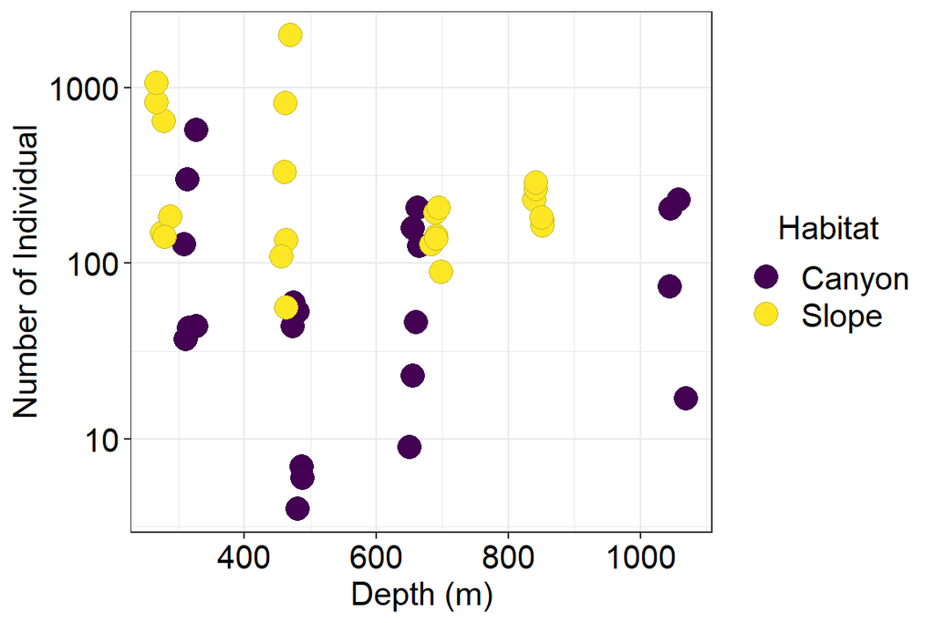

```r
ggplot(data=cbind(Abund=nema_total$Abundance, e),
       aes(x=Depth, y=Abund, colour=Habitat))+
  geom_point(aes(fill=Habitat), pch=21, colour=gray(0, 0.2), size=5,
                  position=position_jitter(width=10))+
  labs(x="Depth (m)", y="Number of Individual")+
  scale_fill_viridis(discrete = TRUE)+
  scale_color_viridis(discrete = TRUE)+
  scale_y_log10()+
  theme_bw() %+replace% large
```

```r
# Linear regression
hl <- splitBy(~Habitat, cbind(Abund=nema_total$Abundance, e))
lapply(hl, FUN=function(x)summary(lm(log10(Abund)~Depth, data=x)))
```

```
## $Canyon
##
## Call:
## lm(formula = log10(Abund) ~ Depth, data = x)
##
## Residuals:
##     Min      1Q  Median      3Q     Max
## -1.1063 -0.3078 -0.0109  0.4568  1.0763
##
## Coefficients:
##              Estimate Std. Error t value Pr(>|t|)
## (Intercept) 1.6341020  0.3236969   5.048 6.15e-05 ***
## Depth       0.0001524  0.0005049   0.302    0.766
## ---
## Signif. codes:  0 '***' 0.001 '**' 0.01 '*' 0.05 '.' 0.1 ' ' 1
##
## Residual standard error: 0.5994 on 20 degrees of freedom
## Multiple R-squared:  0.004536,   Adjusted R-squared:  -0.04524
## F-statistic: 0.09113 on 1 and 20 DF,  p-value: 0.7659
##
##
## $Slope
##
## Call:
## lm(formula = log10(Abund) ~ Depth, data = x)
##
## Residuals:
##      Min       1Q   Median       3Q      Max
## -0.67963 -0.26824 -0.00042  0.20776  0.87025
##
## Coefficients:
##               Estimate Std. Error t value Pr(>|t|)
## (Intercept)  2.6715942  0.2066284  12.929 9.37e-12 ***
## Depth       -0.0005277  0.0003390  -1.557    0.134
## ---
## Signif. codes:  0 '***' 0.001 '**' 0.01 '*' 0.05 '.' 0.1 ' ' 1
##
## Residual standard error: 0.3605 on 22 degrees of freedom
## Multiple R-squared:  0.09922,    Adjusted R-squared:  0.05827
## F-statistic: 2.423 on 1 and 22 DF,  p-value: 0.1338
```

```r
# Linear Mixed-Effects Models
f <- lme(fixed = log10(Abund) ~ Habitat*Depth, random = ~1|Cruise, data=cbind(Abund=nema_total$Abundance, e), method = "REML", weights=varIdent(form=~1|Cruise))
summary(f)
```

```
## Linear mixed-effects model fit by REML
##  Data: cbind(Abund = nema_total$Abundance, e)
##        AIC      BIC    logLik
##   102.1094 114.2731 -44.05468
##
## Random effects:
##  Formula: ~1 | Cruise
##          (Intercept)  Residual
## StdDev: 3.496759e-05 0.2890627
##
## Variance function:
##  Structure: Different standard deviations per stratum
##  Formula: ~1 | Cruise
##  Parameter estimates:
## OR1_1114 OR1_1126
## 1.000000 2.524732
## Fixed effects: log10(Abund) ~ Habitat * Depth
##                         Value  Std.Error DF   t-value p-value
## (Intercept)         2.0063806 0.19639775 41 10.215904  0.0000
## HabitatSlope        0.2006568 0.29346483 41  0.683751  0.4980
## Depth               0.0000416 0.00029216 41  0.142463  0.8874
## HabitatSlope:Depth -0.0000646 0.00046186 41 -0.139797  0.8895
##  Correlation:
##                    (Intr) HbttSl Depth
## HabitatSlope       -0.669
## Depth              -0.917  0.613
## HabitatSlope:Depth  0.580 -0.926 -0.633
##
## Standardized Within-Group Residuals:
##         Min          Q1         Med          Q3         Max
## -1.95201291 -0.62398144  0.01199247  0.54604038  2.55756015
##
## Number of Observations: 46
## Number of Groups: 2
```

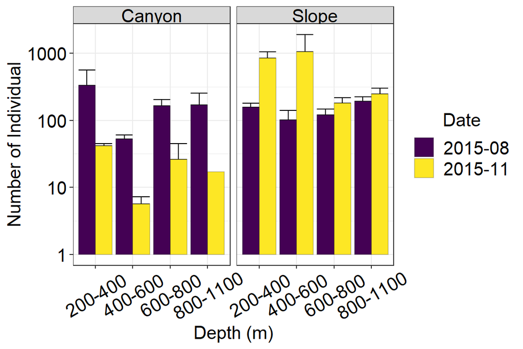

```r
out <- summaryBy(Abund~Cruise+Station+Habitat+Zone, data=cbind(Abund=nema_total$Abundance, e), FUN=c(mean, sd))
out$Date <- factor(out$Cruise, labels=c("2015-08", "2015-11"))
names(out)[5:6] <- c("Abund", "sd")

ggplot(data=out, aes(x=Zone, y=Abund, ymin=Abund, ymax=Abund+sd, fill=Date))+
  geom_errorbar(position="dodge")+
  geom_bar(stat="identity", position="dodge", colour=gray(0, 0.2))+
  facet_wrap(~Habitat)+
  labs(x="Depth (m)", y="Number of Individual")+
  scale_fill_viridis(discrete = TRUE)+
  scale_color_viridis(discrete = TRUE)+
  scale_y_log10()+
  theme_bw() %+replace% large %+replace% theme(axis.text.x=element_text(angle=30))
```

# Estimate Hill Numbers

- Bootstrap confidence interval (1000 iterations)

```r
q0 <- iNEXT(t(b), q = 0, size=1:200, nboot=1000)
q1 <- iNEXT(t(b), q = 1, size=1:200, nboot=1000)
q2 <- iNEXT(t(b), q = 2, size=1:200, nboot=1000)
save(list=c("q0", "q1", "q2"), file="../rda/HillNumbers.rda")
```

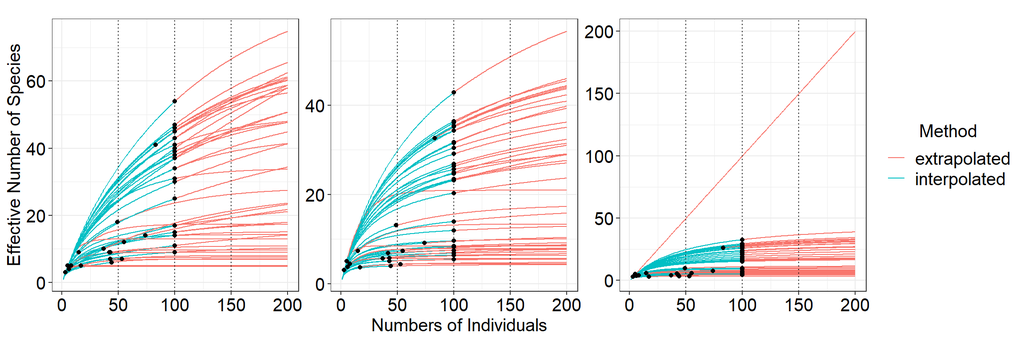

```r
load("../rda/HillNumbers.rda")

h <- rbind(ldply(q0$iNextEst, .id="Sample"),
           ldply(q1$iNextEst, .id="Sample"),
           ldply(q2$iNextEst, .id="Sample"))

ggplot()+
  geom_line(data= subset(h, method!="observed"),
            aes(x=m, y=qD, colour=method, group=Sample))+
  geom_point(data= subset(h, method=="observed"),
             aes(x=m, y=qD, group=Sample))+
  geom_vline(xintercept = c(50, 100, 150), linetype=3)+
  facet_wrap(~order, scale="free")+
  labs(x = "Numbers of Individuals", y = "Effective Number of Species",
       colour="Method")+
  theme_bw()%+replace% large %+replace% no_strip
```

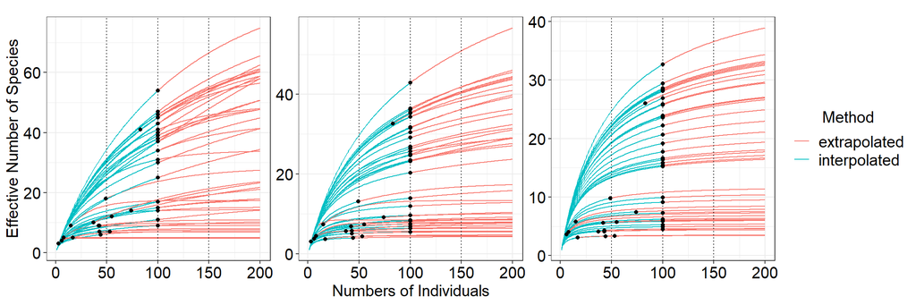

```r
h <- subset(h, !(order==2 & Sample == "OR1_1126_GC2_1_9_2" | Sample == "OR1_1126_GC2_1_9_3"))

ggplot()+
  geom_line(data= subset(h, method!="observed"),
            aes(x=m, y=qD, colour=method, group=Sample))+
  geom_point(data= subset(h, method=="observed"),
             aes(x=m, y=qD, group=Sample))+
  geom_vline(xintercept = c(50, 100, 150), linetype=3)+
  facet_wrap(~order, scale="free")+
  labs(x = "Numbers of Individuals", y = "Effective Number of Species",
       colour="Method")+
  theme_bw()%+replace% large %+replace% no_strip
```

Fig. X. Size-based diversity accumulation curves based on species richness (left), exponential Shannon (middle) and inversed Simpson indices (right). The blue lines indicate the interpolated (rarefied) and red lines indicate extrapolated parts of the accumulation curves based on 1000 permutations. Dotted symbols indicate the observed diversity values. The Hill numbers of order q = 2 (inversed Simpson) for sample “OR1_1126_GC2_1_9_2” and “OR1_1126_GC2_1_9_3” can not be properly estimated and thus were eliminated.

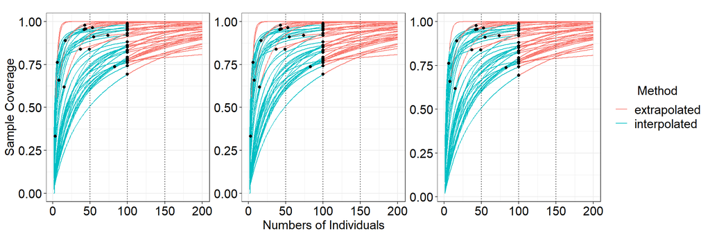

```r
ggplot()+
  geom_line(data= subset(h, method!="observed"),
            aes(x=m, y=SC, colour=method, group=Sample))+
  geom_point(data= subset(h, method=="observed"),
             aes(x=m, y=SC, group=Sample))+
  geom_vline(xintercept = c(50, 100, 150), linetype=3)+
  facet_wrap(~order, scale="free")+
  labs(x = "Numbers of Individuals", y = "Sample Coverage",
       colour="Method")+
  theme_bw()%+replace% large %+replace% no_strip
```

Fig. X. Sample coverage based on species richness (left), exponential Shannon (middle) and inversed Simpson indices (right). The blue lines indicate the interpolated (rarefied) and red lines indicate extrapolated parts of the accumulation curves based on 1000 permutations. Dotted symbols indicate the observed diversity values. The Hill numbers of order q = 2 (inversed Simpson) for sample “OR1_1126_GC2_1_9_2” and “OR1_1126_GC2_1_9_3” can not be properly estimated and thus were eliminated.

```r
# Minimum sample coverage for each order q
min(ldply(lapply(splitBy(~order+Sample, subset(h, order==0)), FUN=function(x)x[dim(x)[1],]))$SC)
```

```
## [1] 0.807
```

```r
min(ldply(lapply(splitBy(~order+Sample, subset(h, order==1)), FUN=function(x)x[dim(x)[1],]))$SC)
```

```
## [1] 0.807
```

```r
min(ldply(lapply(splitBy(~order+Sample, subset(h, order==2)), FUN=function(x)x[dim(x)[1],]))$SC)
```

```
## [1] 0.807
```

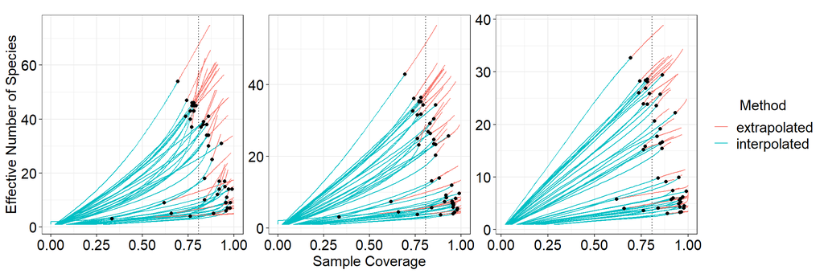

```r
# SC = 0.807

ggplot()+
  geom_line(data= subset(h, method!="observed"),
            aes(x=SC, y=qD, colour=method, group=Sample))+
  geom_point(data= subset(h, method=="observed"),
             aes(x=SC, y=qD, group=Sample))+
  geom_vline(xintercept = c(0.807), linetype=3)+
  facet_wrap(~order, scale="free")+
  labs(x = "Sample Coverage", y = "Effective Number of Species",
       colour="Method")+
  theme_bw()%+replace% large %+replace% no_strip
```

Fig. X. Coverage-based Diversity accumulation curves based on species richness (left), exponential Shannon (middle) and inversed Simpson indices (right) from surface. The blue lines indicate the interpolated (rarefied) and red lines indicate extrapolated parts of the accumulation curves based on 1000 permutations. Dotted symbols indicate the observed diversity values. The vertical dashed line (80.7%) shows the sample with the lowest sample coverage. The Hill numbers of order q = 2 (inversed Simpson) for sample “OR1_1126_GC2_1_9_2” and “OR1_1126_GC2_1_9_3” can not be properly estimated and thus were eliminated.

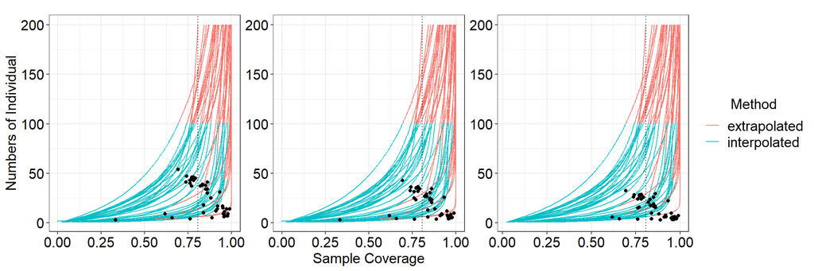

```r
ggplot()+
  geom_line(data= subset(h, method!="observed"),
            aes(x=SC, y=m, colour=method, group=Sample))+
  geom_point(data= subset(h, method=="observed"),
             aes(x=SC, y=qD, group=Sample))+
  geom_vline(xintercept = c(0.807), linetype=3)+
  facet_wrap(~order, scale="free")+
  labs(x = "Sample Coverage", y = "Numbers of Individual",
       colour="Method")+
  theme_bw()%+replace% large %+replace% no_strip
```

Fig. X. Sample size as a function of sample coverage based on species richness (left), exponential Shannon (middle) and inversed Simpson indices (right) from surface. The blue lines indicate the interpolated (rarefied) and red lines indicate extrapolated parts of the accumulation curves based on 1000 permutations. Dotted symbols indicate the observed diversity values. The vertical dashed line (80.7%) shows the sample with the lowest sample coverage. The Hill numbers of order q = 2 (inversed Simpson) for sample “OR1_1126_GC2_1_9_2” and “OR1_1126_GC2_1_9_3” can not be properly estimated and thus were eliminated.

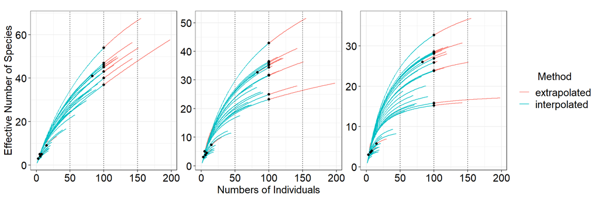

```r
# ~80.7% sample coverage
h0 <- lapply(q0$iNextEst, FUN=function(x) {
  d<-abs(x$SC-0.807)
  x[1:which(d==min(d)),]
  }) %>% ldply(.id="Sample")

h1 <- lapply(q1$iNextEst, FUN=function(x) {
  d<-abs(x$SC-0.807)
  x[1:which(d==min(d)),]
  }) %>% ldply(.id="Sample")

h2 <- lapply(q2$iNextEst, FUN=function(x) {
  d<-abs(x$SC-0.807)
  x[1:which(d==min(d)),]
  }) %>% ldply(.id="Sample")

h <- rbind(h0, h1, h2)
h <- subset(h, !(order==2 & Sample == "OR1_1126_GC2_1_9_3"))

ggplot()+
  geom_line(data= subset(h, method!="observed"),
            aes(x=m, y=qD, colour=method, group=Sample))+
  geom_point(data= subset(h, method=="observed"),
             aes(x=m, y=qD, group=Sample))+
  geom_vline(xintercept = c(50, 100, 150), linetype=3)+
  facet_wrap(~order, scale="free")+
  labs(x = "Numbers of Individuals", y = "Effective Number of Species",
       colour="Method")+
  theme_bw()%+replace% large %+replace% no_strip
```

Fig. X. Size-based diversity accumulation curves based on species richness (left), exponential Shannon (middle) and inversed Simpson indices (right). The blue lines indicate the interpolated (rarefied) and red lines indicate extrapolated parts of the accumulation curves based on 1000 permutations. Dotted symbols indicate the observed diversity values. Sample size (numbers of individuals) and the Hill numbers are cut off by 80.7% sample coverage. The Hill numbers of order q = 2 (inversed Simpson) for sample “OR1_1126_GC2_1_9_3” can not be properly estimated and thus were eliminated.

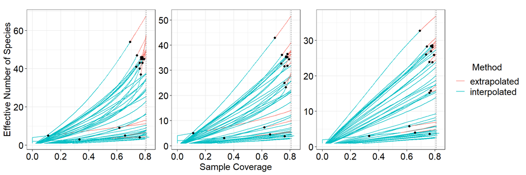

```r
ggplot()+
  geom_line(data= subset(h, method!="observed"),
            aes(x=SC, y=qD, colour=method, group=Sample))+
  geom_point(data= subset(h, method=="observed"),
             aes(x=SC, y=qD, group=Sample))+
  geom_vline(xintercept = c(0.807), linetype=3)+
  facet_wrap(~order, scale="free")+
  labs(x = "Sample Coverage", y = "Effective Number of Species",
       colour="Method")+
  theme_bw()%+replace% large %+replace% no_strip
```

Fig. X. Coverage-based Diversity accumulation curves based on species richness (left), exponential Shannon (middle) and inversed Simpson indices (right) from surface. The blue lines indicate the interpolated (rarefied) and red lines indicate extrapolated parts of the accumulation curves based on 1000 permutations. Dotted symbols indicate the observed diversity values. Sample size (numbers of individuals) and the Hill numbers are cut off by 80.7% sample coverage. The Hill numbers of order q = 2 (inversed Simpson) for sample “OR1_1126_GC2_1_9_3” can not be properly estimated and thus were eliminated.

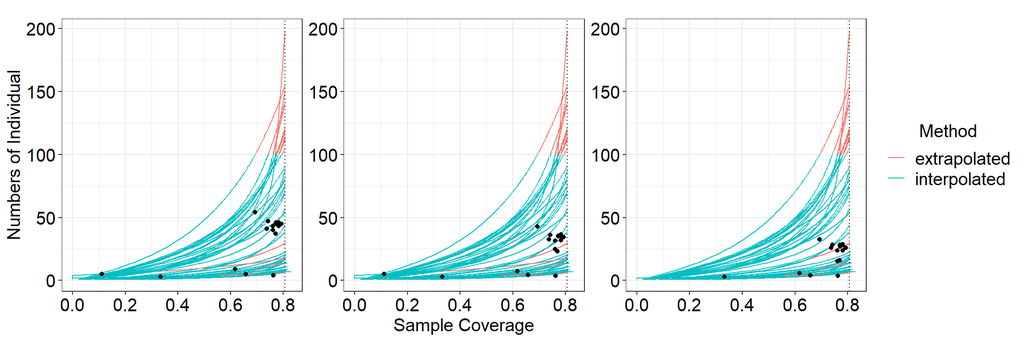

```r
ggplot()+
  geom_line(data= subset(h, method!="observed"),
            aes(x=SC, y=m, colour=method, group=Sample))+
  geom_point(data= subset(h, method=="observed"),
             aes(x=SC, y=qD, group=Sample))+
  geom_vline(xintercept = c(0.807), linetype=3)+
  facet_wrap(~order, scale="free")+
  labs(x = "Sample Coverage", y = "Numbers of Individual",
       colour="Method")+
  theme_bw()%+replace% large %+replace% no_strip
```

Fig. X. Sample size as a function of sample coverage based on species richness (left), exponential Shannon (middle) and inversed Simpson indices (right) from surface. The blue lines indicate the interpolated (rarefied) and red lines indicate extrapolated parts of the accumulation curves based on 1000 permutations. Dotted symbols indicate the observed diversity values. Sample size (numbers of individuals) and the Hill numbers are cut off by 80.7% sample coverage. The Hill numbers of order q = 2 (inversed Simpson) for sample “OR1_1126_GC2_1_9_3” can not be properly estimated and thus were eliminated.

```r
# ~80.7% sample coverage
h0 <- lapply(q0$iNextEst, FUN=function(x) {
  d<-abs(x$SC-0.807)
  o <- subset(x, d==min(d))
  o[dim(o)[1],]
  }) %>% ldply(.id="Sample")
round(mean(h0$SC), 3)
```

```
## [1] 0.808
```

```r
h1 <- lapply(q1$iNextEst, FUN=function(x) {
  d<-abs(x$SC-0.807)
  o <- subset(x, d==min(d))
  o[dim(o)[1],]
  }) %>% ldply(.id="Sample")
round(mean(h1$SC), 3)
```

```
## [1] 0.808
```

```r
h2 <- lapply(q2$iNextEst, FUN=function(x) {
  d<-abs(x$SC-0.807)
  o <- subset(x, d==min(d))
  o[dim(o)[1],]
  }) %>% ldply(.id="Sample")
# Set the bad diversity estimates to NA
h2[h2$Sample == "OR1_1126_GC2_1_9_3", c("qD", "qD.LCL", "qD.UCL", "SC", "SC.LCL", "SC.UCL")] <- NA
round(mean(h2$SC, na.rm=TRUE), 3)
```

```
## [1] 0.808
```

```r
# 100 randomly selected individual
#h0 <- subset(ldply(q0$iNextEst, .id="Sample"), m==100)
#h1 <- subset(ldply(q1$iNextEst, .id="Sample"), m==100)
#h2 <- subset(ldply(q2$iNextEst, .id="Sample"), m==100)
# Set the bad diversity estimates to NA
#h2[h2$Sample == "OR1_1126_GC2_1_9_2"|h2$Sample == "OR1_1126_GC2_1_9_3", c("qD", "qD.LCL", "qD.UCL", "SC", "SC.LCL", "SC.UCL")] <- NA
```

## Observed number of species

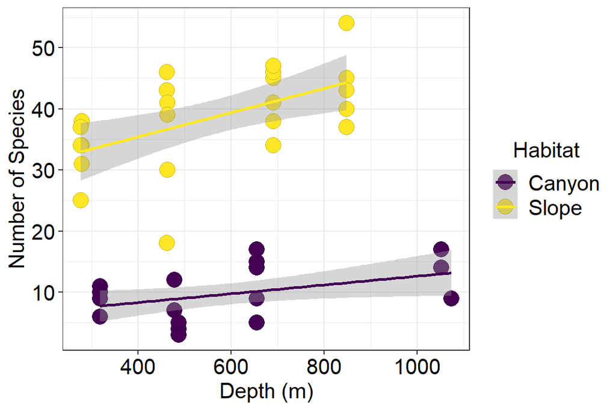

```r
ggplot(data=cbind(q0$DataInfo, e),
       aes(x=Depth, y=S.obs, colour=Habitat))+
  geom_point(aes(fill=Habitat), pch=21, colour=gray(0, 0.2), size=5)+
  stat_smooth(method="lm", fill="gray60")+
  labs(x="Depth (m)", y="Number of Species")+
  scale_fill_viridis(discrete = TRUE)+
  scale_color_viridis(discrete = TRUE)+
  theme_bw() %+replace% large
```

```r
# Linear regression
hl <- splitBy(~Habitat, subset(cbind(q0$DataInfo, e), site!="OR1_1126_GC2_1_9_3"))
lapply(hl, FUN=function(x)summary(lm(S.obs~Depth, data=x)))
```

```
## $Canyon
##
## Call:
## lm(formula = S.obs ~ Depth, data = x)
##
## Residuals:
##     Min      1Q  Median      3Q     Max
## -6.1679 -2.1059  0.9448  2.9969  6.6742
##
## Coefficients:
##             Estimate Std. Error t value Pr(>|t|)
## (Intercept) 5.811396   2.114571   2.748   0.0128 *
## Depth       0.006892   0.003265   2.111   0.0483 *
## ---
## Signif. codes:  0 '***' 0.001 '**' 0.01 '*' 0.05 '.' 0.1 ' ' 1
##
## Residual standard error: 3.862 on 19 degrees of freedom
## Multiple R-squared:  0.1899, Adjusted R-squared:  0.1473
## F-statistic: 4.455 on 1 and 19 DF,  p-value: 0.04828
##
##
## $Slope
##
## Call:
## lm(formula = S.obs ~ Depth, data = x)
##
## Residuals:
##      Min       1Q   Median       3Q      Max
## -18.6569  -3.4628   0.8298   4.4476   9.6867
##
## Coefficients:
##              Estimate Std. Error t value Pr(>|t|)
## (Intercept) 27.493078   3.780411   7.273 2.77e-07 ***
## Depth        0.019835   0.006202   3.198  0.00415 **
## ---
## Signif. codes:  0 '***' 0.001 '**' 0.01 '*' 0.05 '.' 0.1 ' ' 1
##
## Residual standard error: 6.595 on 22 degrees of freedom
## Multiple R-squared:  0.3174, Adjusted R-squared:  0.2864
## F-statistic: 10.23 on 1 and 22 DF,  p-value: 0.004148
```

```r
# Linear Mixed-Effects Models
f <- lme(fixed = S.obs ~ Habitat*Depth, random = ~1|Cruise, data=cbind(q0$DataInfo, e), method = "REML", weights=varIdent(form=~1|Cruise))
summary(f)
```

```
## Linear mixed-effects model fit by REML
##  Data: cbind(q0$DataInfo, e)
##        AIC     BIC    logLik
##   303.9113 316.075 -144.9557
##
## Random effects:
##  Formula: ~1 | Cruise
##         (Intercept) Residual
## StdDev:    2.925301 5.698445
##
## Variance function:
##  Structure: Different standard deviations per stratum
##  Formula: ~1 | Cruise
##  Parameter estimates:
##  OR1_1114  OR1_1126
## 1.0000000 0.7397259
## Fixed effects: S.obs ~ Habitat * Depth
##                        Value Std.Error DF  t-value p-value
## (Intercept)         6.331042  3.385372 41 1.870117  0.0686
## HabitatSlope       22.201319  3.821016 41 5.810318  0.0000
## Depth               0.004999  0.004250 41 1.176292  0.2463
## HabitatSlope:Depth  0.013136  0.006193 41 2.121154  0.0400
##  Correlation:
##                    (Intr) HbttSl Depth
## HabitatSlope       -0.549
## Depth              -0.729  0.640
## HabitatSlope:Depth  0.500 -0.928 -0.686
##
## Standardized Within-Group Residuals:
##         Min          Q1         Med          Q3         Max
## -3.66031978 -0.58929614  0.08206964  0.59555922  1.87466202
##
## Number of Observations: 46
## Number of Groups: 2
```

```r
# Normalized enivronmental data to mean zero and unit variance
es <- as.data.frame(scale(e[, c(-1:-9, -11:-13, -35)]))

# General linear Models
dat <- cbind(q0$DataInfo, es)
f <- gls(S.obs ~ Speed+CN+Salinity+over20+TOC+transmissometer+Temperature, data=dat)
summary(f)
```

```
## Generalized least squares fit by REML
##   Model: S.obs ~ Speed + CN + Salinity + over20 + TOC + transmissometer +      Temperature
##   Data: dat
##        AIC      BIC    logLik
##   289.7736 304.5118 -135.8868
##
## Coefficients:
##                     Value Std.Error   t-value p-value
## (Intercept)     24.869565 0.9134361 27.226388  0.0000
## Speed           -4.072504 2.5941771 -1.569863  0.1247
## CN               2.846191 1.4572554  1.953118  0.0582
## Salinity        -1.033859 1.1547875 -0.895280  0.3763
## over20           3.761849 2.0110433  1.870596  0.0691
## TOC              8.718334 2.4559958  3.549816  0.0010
## transmissometer  6.352658 1.9346184  3.283675  0.0022
## Temperature      3.411644 1.0665627  3.198728  0.0028
##
##  Correlation:
##                 (Intr) Speed  CN     Salnty over20 TOC    trnsms
## Speed            0.000
## CN               0.000 -0.375
## Salinity         0.000 -0.455 -0.082
## over20           0.000 -0.399  0.282  0.221
## TOC              0.000  0.529 -0.674 -0.017  0.042
## transmissometer  0.000  0.275  0.419 -0.291  0.307 -0.287
## Temperature      0.000  0.038 -0.049 -0.231 -0.252  0.115 -0.174
##
## Standardized residuals:
##        Min         Q1        Med         Q3        Max
## -3.8607428 -0.3782151  0.1524285  0.4297129  2.3838042
##
## Residual standard error: 6.195225
## Degrees of freedom: 46 total; 38 residual
```

```r
# Model selection
ms <- dredge(f)
kable(ms[1:10,])
```

|  | (Intercept) | CN | over20 | Salinity | Speed | Temperature | TOC | transmissometer | df | logLik | AICc | delta | weight |
| --- | --- | --- | --- | --- | --- | --- | --- | --- | --- | --- | --- | --- | --- |
| 124 | 24.86957 | 2.738712 | 4.159501 | NA | -5.128489 | 3.191529 | 8.681605 | 5.849081 | 8 | -137.3501 | 294.5922 | 0.000000 | 0.33440724 |
| 128 | 24.86957 | 2.846191 | 3.761849 | -1.0338587 | -4.072504 | 3.411644 | 8.718334 | 6.352658 | 9 | -135.8868 | 294.7736 | 0.181378 | 0.30541470 |
| 123 | 24.86957 | NA | 3.016535 | NA | -3.105660 | 3.328553 | 11.819532 | 4.402776 | 7 | -140.3871 | 297.7216 | 3.129433 | 0.06994039 |
| 120 | 24.86957 | 1.989147 | 2.503593 | -1.8581164 | NA | 3.475350 | 10.759415 | 7.186852 | 8 | -138.9778 | 297.8475 | 3.255330 | 0.06567342 |
| 127 | 24.86957 | NA | 2.653556 | -0.8480524 | -2.174340 | 3.513520 | 11.950674 | 4.769291 | 8 | -139.0411 | 297.9742 | 3.381993 | 0.06164321 |
| 126 | 24.86957 | 2.077025 | NA | -1.5109534 | -2.138464 | 3.913893 | 8.527041 | 5.241269 | 8 | -139.2155 | 298.3230 | 3.730774 | 0.05177836 |
| 122 | 24.86957 | 1.786972 | NA | NA | -3.446792 | 3.657273 | 8.439543 | 4.287066 | 7 | -141.1272 | 299.2017 | 4.609540 | 0.03336773 |
| 119 | 24.86957 | NA | 2.079355 | -1.3947274 | NA | 3.534034 | 12.613833 | 5.583506 | 7 | -141.2533 | 299.4540 | 4.861833 | 0.02941319 |
| 118 | 24.86957 | 1.702611 | NA | -1.9258852 | NA | 3.848792 | 9.841144 | 5.994080 | 7 | -141.4115 | 299.7705 | 5.178267 | 0.02510899 |
| 116 | 24.86957 | 1.242151 | 2.665338 | NA | NA | 3.014074 | 11.875275 | 6.535996 | 7 | -141.4883 | 299.9241 | 5.331869 | 0.02325279 |

```r
# Model averaging
ma <- model.avg(ms, fit=TRUE)
kable(summary(ma)$coefmat.full)
```

|  | Estimate | Std. Error | Adjusted SE | z value | Pr(>\|z\|) |
| --- | --- | --- | --- | --- | --- |
| (Intercept) | 24.8695652 | 0.9288256 | 0.9584904 | 25.9465971 | 0.0000000 |
| CN | 1.9785272 | 1.7180435 | 1.7485160 | 1.1315466 | 0.2578251 |
| over20 | 2.9852835 | 2.3299183 | 2.3748593 | 1.2570360 | 0.2087406 |
| Speed | -3.3619790 | 2.8755127 | 2.9298061 | 1.1475090 | 0.2511713 |
| Temperature | 3.3526578 | 1.1630128 | 1.1936071 | 2.8088454 | 0.0049720 |
| TOC | 9.6147988 | 2.7367370 | 2.7985899 | 3.4355870 | 0.0005913 |
| transmissometer | 5.6859078 | 2.1301232 | 2.1806382 | 2.6074512 | 0.0091219 |
| Salinity | -0.6321866 | 1.0547722 | 1.0757346 | 0.5876789 | 0.5567478 |

```r
# Best model
b <- get.models(ms, subset=1)[[1]]
kable(summary(b)$tTable)
```

|  | Value | Std.Error | t-value | p-value |
| --- | --- | --- | --- | --- |
| (Intercept) | 24.869565 | 0.9111089 | 27.295931 | 0.0000000 |
| CN | 2.738712 | 1.4486019 | 1.890590 | 0.0661258 |
| over20 | 4.159501 | 1.9563832 | 2.126118 | 0.0398782 |
| Speed | -5.128489 | 2.3046391 | -2.225289 | 0.0319149 |
| Temperature | 3.191529 | 1.0351938 | 3.083025 | 0.0037527 |
| TOC | 8.681605 | 2.4493967 | 3.544385 | 0.0010401 |
| transmissometer | 5.849081 | 1.8463284 | 3.167953 | 0.0029809 |

```r
# Relative importance
kable(summary(ma)$sw)
```

|  | x |
| --- | --- |
| TOC | 0.9979338 |
| transmissometer | 0.9840205 |
| Temperature | 0.9834276 |
| over20 | 0.8347704 |
| Speed | 0.8280281 |
| CN | 0.7764000 |
| Salinity | 0.5264857 |

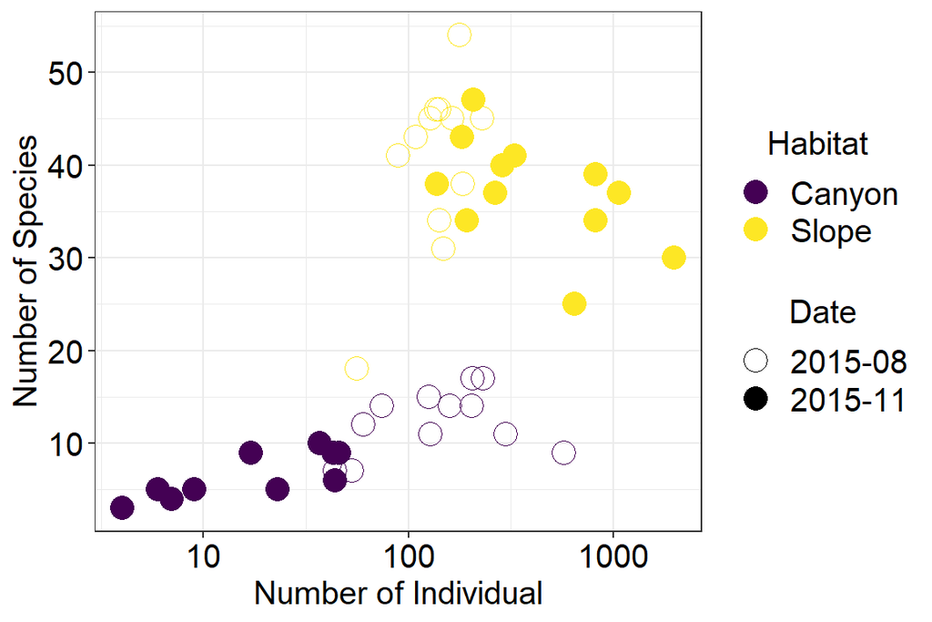

```r
out <- cbind(q0$DataInfo, Abund=nema_total$Abundance,e)
out$Date <- factor(out$Cruise, labels=c("2015-08", "2015-11"))
ggplot(data=out, aes(x=Abund, y=S.obs, colour=Habitat, shape=Date))+
  geom_point(size=5)+
  labs(x="Number of Individual", y="Number of Species")+
  scale_shape_manual(values=c(1, 19))+
  scale_x_log10()+
  scale_color_viridis(discrete = TRUE)+
  theme_bw() %+replace% large
```

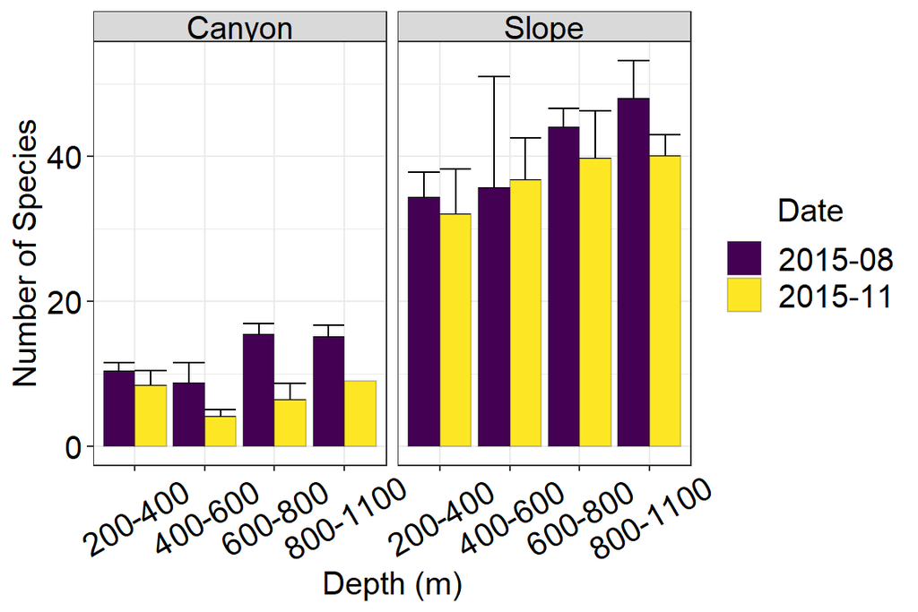

```r
out <- summaryBy(S.obs~Cruise+Station+Habitat+Zone, data=cbind(q0$DataInfo, e), FUN=c(mean, sd))
out$Date <- factor(out$Cruise, labels=c("2015-08", "2015-11"))
names(out)[5:6] <- c("S.obs", "sd")

ggplot(data=out, aes(x=Zone, y=S.obs, ymin=S.obs, ymax=S.obs+sd, fill=Date))+
  geom_errorbar(position="dodge")+
  geom_bar(stat="identity", position="dodge", colour=gray(0, 0.2))+
  facet_wrap(~Habitat)+
  labs(x="Depth (m)", y="Number of Species")+
  scale_fill_viridis(discrete = TRUE)+
  scale_color_viridis(discrete = TRUE)+
  theme_bw() %+replace% large %+replace% theme(axis.text.x=element_text(angle=30))
```

## q=0 or species richness

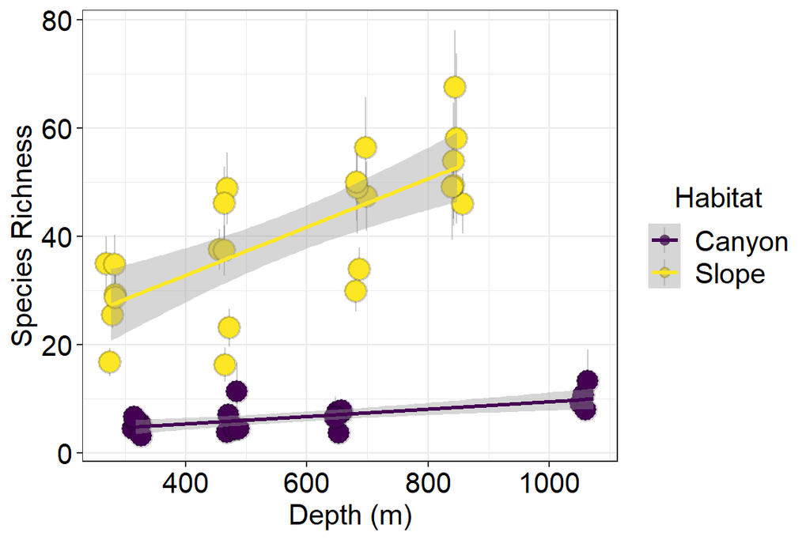

```r
ggplot(data=cbind(h0, e),
       aes(x=Depth, y=qD, ymin=qD.LCL, ymax=qD.UCL, colour=Habitat))+
  geom_pointrange(aes(fill=Habitat), pch=21, colour=gray(0, 0.2), fatten = 10,
                  position=position_jitter(width=10))+
  stat_smooth(method="lm", fill="gray60")+
  labs(x="Depth (m)", y="Species Richness")+
  scale_fill_viridis(discrete = TRUE)+
  scale_color_viridis(discrete = TRUE)+
  theme_bw() %+replace% large
```

```r
# Linear regression
hl <- splitBy(~Habitat, subset(cbind(h0, e), Sample!="OR1_1126_GC2_1_9_3"))
lapply(hl, FUN=function(x)summary(lm(qD~Depth, data=x)))
```

```
## $Canyon
##
## Call:
## lm(formula = qD ~ Depth, data = x)
##
## Residuals:
##     Min      1Q  Median      3Q     Max
## -3.2293 -1.2549 -0.0272  0.9347  3.2897
##
## Coefficients:
##             Estimate Std. Error t value Pr(>|t|)
## (Intercept) 2.115494   0.875057   2.418   0.0258 *
## Depth       0.007282   0.001351   5.389 3.36e-05 ***
## ---
## Signif. codes:  0 '***' 0.001 '**' 0.01 '*' 0.05 '.' 0.1 ' ' 1
##
## Residual standard error: 1.598 on 19 degrees of freedom
## Multiple R-squared:  0.6045, Adjusted R-squared:  0.5837
## F-statistic: 29.04 on 1 and 19 DF,  p-value: 3.36e-05
##
##
## $Slope
##
## Call:
## lm(formula = qD ~ Depth, data = x)
##
## Residuals:
##     Min      1Q  Median      3Q     Max
## -19.391  -4.513   1.702   5.794  14.772
##
## Coefficients:
##              Estimate Std. Error t value Pr(>|t|)
## (Intercept) 15.049996   5.348479   2.814   0.0101 *
## Depth        0.044530   0.008774   5.075 4.39e-05 ***
## ---
## Signif. codes:  0 '***' 0.001 '**' 0.01 '*' 0.05 '.' 0.1 ' ' 1
##
## Residual standard error: 9.331 on 22 degrees of freedom
## Multiple R-squared:  0.5394, Adjusted R-squared:  0.5184
## F-statistic: 25.76 on 1 and 22 DF,  p-value: 4.391e-05
```

```r
# Linear Mixed-Effects Models
f <- lme(fixed = qD ~ Habitat*Depth, random = ~1|Cruise, data=cbind(h0, e), method = "REML", weights=varIdent(form=~1|Cruise))
summary(f)
```

```
## Linear mixed-effects model fit by REML
##  Data: cbind(h0, e)
##       AIC      BIC    logLik
##   329.681 341.8447 -157.8405
##
## Random effects:
##  Formula: ~1 | Cruise
##         (Intercept) Residual
## StdDev: 0.006223993 6.923198
##
## Variance function:
##  Structure: Different standard deviations per stratum
##  Formula: ~1 | Cruise
##  Parameter estimates:
##  OR1_1114  OR1_1126
## 1.0000000 0.9899895
## Fixed effects: qD ~ Habitat * Depth
##                        Value Std.Error DF  t-value p-value
## (Intercept)         2.605861  3.722529 41 0.700024  0.4879
## HabitatSlope       12.420823  5.426412 41 2.288957  0.0273
## Depth               0.006886  0.005810 41 1.185069  0.2428
## HabitatSlope:Depth  0.037648  0.008701 41 4.326758  0.0001
##  Correlation:
##                    (Intr) HbttSl Depth
## HabitatSlope       -0.686
## Depth              -0.919  0.630
## HabitatSlope:Depth  0.614 -0.927 -0.668
##
## Standardized Within-Group Residuals:
##        Min         Q1        Med         Q3        Max
## -2.7977607 -0.2697895  0.0821778  0.2734442  2.1366416
##
## Number of Observations: 46
## Number of Groups: 2
```

```r
# General linear Models
dat <- cbind(h0, es)
f <- gls(qD ~ Speed+CN+Salinity+over20+TOC+transmissometer+Temperature, data=dat)
summary(f)
```

```
## Generalized least squares fit by REML
##   Model: qD ~ Speed + CN + Salinity + over20 + TOC + transmissometer +      Temperature
##   Data: dat
##       AIC      BIC   logLik
##   315.704 330.4423 -148.852
##
## Coefficients:
##                     Value Std.Error   t-value p-value
## (Intercept)     24.271609  1.284858 18.890497  0.0000
## Speed            0.526256  3.649023  0.144218  0.8861
## CN               0.536161  2.049806  0.261567  0.7951
## Salinity        -1.887107  1.624348 -1.161763  0.2526
## over20           6.000107  2.828775  2.121097  0.0405
## TOC             15.036340  3.454655  4.352487  0.0001
## transmissometer  9.693524  2.721274  3.562127  0.0010
## Temperature      0.930168  1.500249  0.620009  0.5390
##
##  Correlation:
##                 (Intr) Speed  CN     Salnty over20 TOC    trnsms
## Speed            0.000
## CN               0.000 -0.375
## Salinity         0.000 -0.455 -0.082
## over20           0.000 -0.399  0.282  0.221
## TOC              0.000  0.529 -0.674 -0.017  0.042
## transmissometer  0.000  0.275  0.419 -0.291  0.307 -0.287
## Temperature      0.000  0.038 -0.049 -0.231 -0.252  0.115 -0.174
##
## Standardized residuals:
##         Min          Q1         Med          Q3         Max
## -2.81037997 -0.43841720 -0.04607807  0.52168270  2.50060550
##
## Residual standard error: 8.714332
## Degrees of freedom: 46 total; 38 residual
```

```r
# Model selection
ms <- dredge(f)
kable(ms[1:10,])
```

|  | (Intercept) | CN | over20 | Salinity | Speed | Temperature | TOC | transmissometer | df | logLik | AICc | delta | weight |
| --- | --- | --- | --- | --- | --- | --- | --- | --- | --- | --- | --- | --- | --- |
| 112 | 24.27161 | 0.5983142 | 6.441625 | -1.654950 | 0.4401757 | NA | 14.79092 | 9.987334 | 8 | -150.3663 | 320.6246 | 0.0000000 | 0.14699462 |
| 128 | 24.27161 | 0.5361605 | 6.000107 | -1.887107 | 0.5262564 | 0.9301681 | 15.03634 | 9.693524 | 9 | -148.8520 | 320.7040 | 0.0794674 | 0.14126849 |
| 127 | 24.27161 | NA | 5.791329 | -1.852106 | 0.8838292 | 0.9493593 | 15.64524 | 9.395252 | 8 | -150.5172 | 320.9264 | 0.3018367 | 0.12640331 |
| 111 | 24.27161 | NA | 6.218276 | -1.610439 | 0.8381696 | NA | 15.46637 | 9.660468 | 7 | -152.0320 | 321.0113 | 0.3867252 | 0.12115048 |
| 108 | 24.27161 | 0.3917459 | 6.937256 | NA | -1.3106206 | NA | 14.82701 | 9.018452 | 7 | -152.2920 | 321.5313 | 0.9067628 | 0.09341151 |
| 124 | 24.27161 | 0.3399781 | 6.725943 | NA | -1.4012386 | 0.5283895 | 14.96930 | 8.774343 | 8 | -150.9301 | 321.7521 | 1.1275842 | 0.08364686 |
| 107 | 24.27161 | NA | 6.780837 | NA | -1.0164715 | NA | 15.27277 | 8.819653 | 6 | -153.9292 | 322.0123 | 1.3877786 | 0.07344279 |
| 120 | 24.27161 | 0.6469094 | 6.162701 | -1.780595 | NA | 0.9219359 | 14.77259 | 9.585728 | 8 | -151.0696 | 322.0310 | 1.4064519 | 0.07276027 |
| 104 | 24.27161 | 0.6906212 | 6.574548 | -1.567452 | NA | NA | 14.57181 | 9.894861 | 7 | -152.5723 | 322.0919 | 1.4673842 | 0.07057697 |
| 123 | 24.27161 | NA | 6.584058 | NA | -1.1501287 | 0.5453994 | 15.35883 | 8.594802 | 7 | -152.5756 | 322.0985 | 1.4739771 | 0.07034470 |

```r
# Model averaging
ma <- model.avg(ms, fit=TRUE)
kable(summary(ma)$coefmat.full)
```

|  | Estimate | Std. Error | Adjusted SE | z value | Pr(>\|z\|) |
| --- | --- | --- | --- | --- | --- |
| (Intercept) | 24.2716087 | 1.272733 | 1.312770 | 18.4888505 | 0.0000000 |
| CN | 0.2219104 | 1.496579 | 1.541829 | 0.1439267 | 0.8855583 |
| over20 | 6.1024600 | 2.874363 | 2.947090 | 2.0706728 | 0.0383894 |
| Salinity | -1.0926663 | 1.479037 | 1.510518 | 0.7233719 | 0.4694515 |
| Speed | 0.0515887 | 2.898433 | 2.981061 | 0.0173055 | 0.9861929 |
| TOC | 15.1363212 | 2.952668 | 3.043042 | 4.9740750 | 0.0000007 |
| transmissometer | 9.2683653 | 2.552381 | 2.627005 | 3.5281111 | 0.0004185 |
| Temperature | 0.4165003 | 1.141632 | 1.172180 | 0.3553211 | 0.7223490 |

```r
# Best model
b <- get.models(ms, subset=1)[[1]]
kable(summary(b)$tTable)
```

|  | Value | Std.Error | t-value | p-value |
| --- | --- | --- | --- | --- |
| (Intercept) | 24.2716087 | 1.274677 | 19.0413722 | 0.0000000 |
| CN | 0.5983142 | 2.031131 | 0.2945720 | 0.7698832 |
| over20 | 6.4416254 | 2.715982 | 2.3717480 | 0.0227360 |
| Salinity | -1.6549498 | 1.568077 | -1.0554008 | 0.2977365 |
| Speed | 0.4401757 | 3.617489 | 0.1216799 | 0.9037773 |
| TOC | 14.7909195 | 3.404710 | 4.3442530 | 0.0000966 |
| transmissometer | 9.9873337 | 2.658463 | 3.7568069 | 0.0005624 |

```r
# Relative importance
kable(summary(ma)$sw)
```

|  | x |
| --- | --- |
| TOC | 0.9999208 |
| transmissometer | 0.9981396 |
| over20 | 0.9604318 |
| Speed | 0.6734034 |
| Salinity | 0.6302552 |
| CN | 0.5431667 |
| Temperature | 0.5025923 |

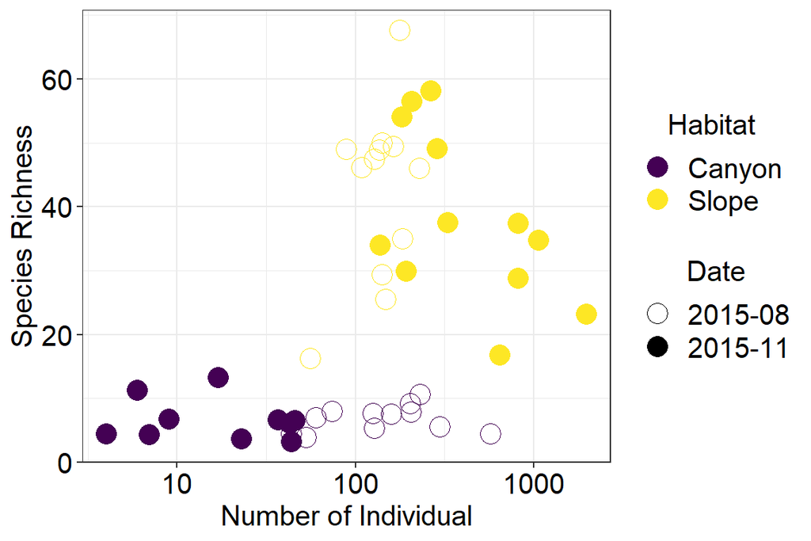

```r
out <- cbind(h0, Abund=nema_total$Abundance,e)
out$Date <- factor(out$Cruise, labels=c("2015-08", "2015-11"))
ggplot(data=out, aes(x=Abund, y=qD, colour=Habitat, shape=Date))+
  geom_point(size=5)+
  labs(x="Number of Individual", y="Species Richness")+
  scale_shape_manual(values=c(1, 19))+
  scale_x_log10()+
  scale_color_viridis(discrete = TRUE)+
  theme_bw() %+replace% large
```

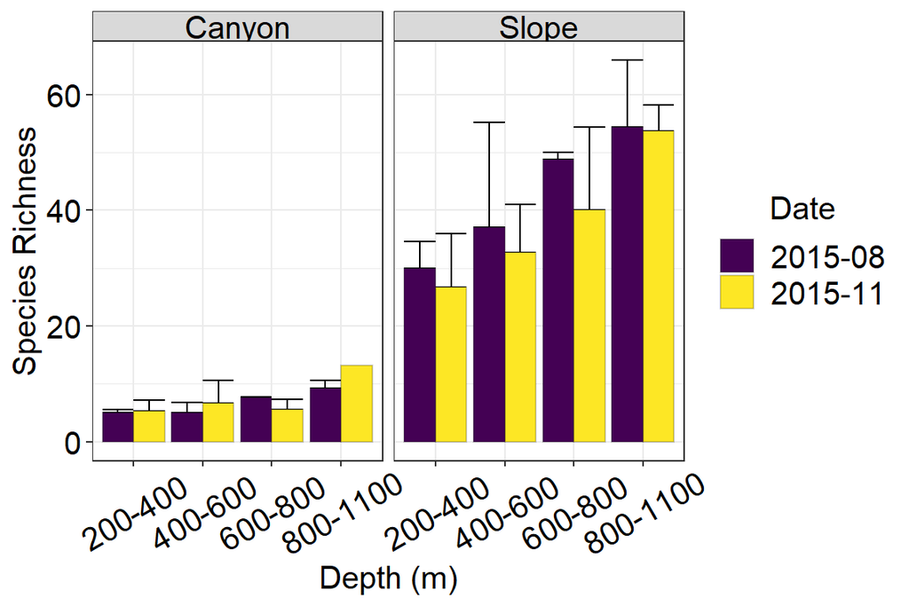

```r
out <- summaryBy(qD~Cruise+Station+Habitat+Zone, data=cbind(h0, e), FUN=c(mean, sd))
out$Date <- factor(out$Cruise, labels=c("2015-08", "2015-11"))
names(out)[5:6] <- c("qD", "sd")

ggplot(data=out, aes(x=Zone, y=qD, ymin=qD, ymax=qD+sd, fill=Date))+
  geom_errorbar(position="dodge")+
  geom_bar(stat="identity", position="dodge", colour=gray(0, 0.2))+
  facet_wrap(~Habitat)+
  labs(x="Depth (m)", y="Species Richness")+
  scale_fill_viridis(discrete = TRUE)+
  scale_color_viridis(discrete = TRUE)+
  theme_bw() %+replace% large %+replace% theme(axis.text.x=element_text(angle=30))
```

## q=1 or exponential Shannon diversity

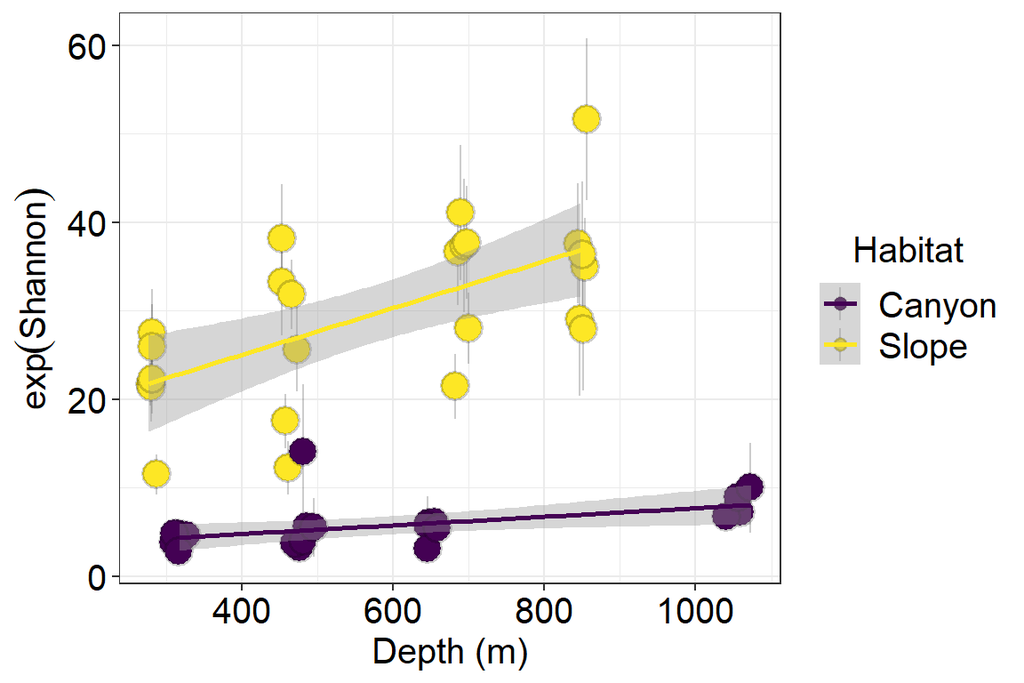

```r
ggplot(data=cbind(h1, e),
       aes(x=Depth, y=qD, ymin=qD.LCL, ymax=qD.UCL, colour=Habitat))+
  geom_pointrange(aes(fill=Habitat), pch=21, colour=gray(0, 0.2), fatten = 10,
                  position=position_jitter(width=10))+
  stat_smooth(method="lm", fill="gray60")+
  labs(x="Depth (m)", y=expression(exp(Shannon)))+
  scale_fill_viridis(discrete = TRUE)+
  scale_color_viridis(discrete = TRUE)+
  theme_bw() %+replace% large
```

```r
# Linear regression
hl <- splitBy(~Habitat, cbind(h1, e))
lapply(hl, FUN=function(x)summary(lm(qD~Depth, data=x)))
```

```
## $Canyon
##
## Call:
## lm(formula = qD ~ Depth, data = x)
##
## Residuals:
##     Min      1Q  Median      3Q     Max
## -2.9655 -1.0708 -0.2075  0.3284  8.8558
##
## Coefficients:
##             Estimate Std. Error t value Pr(>|t|)
## (Intercept) 2.853736   1.242826   2.296   0.0326 *
## Depth       0.004853   0.001939   2.504   0.0211 *
## ---
## Signif. codes:  0 '***' 0.001 '**' 0.01 '*' 0.05 '.' 0.1 ' ' 1
##
## Residual standard error: 2.301 on 20 degrees of freedom
## Multiple R-squared:  0.2386, Adjusted R-squared:  0.2005
## F-statistic: 6.268 on 1 and 20 DF,  p-value: 0.02107
##
##
## $Slope
##
## Call:
## lm(formula = qD ~ Depth, data = x)
##
## Residuals:
##      Min       1Q   Median       3Q      Max
## -14.4430  -5.4764   0.1519   5.0160  14.7052
##
## Coefficients:
##              Estimate Std. Error t value Pr(>|t|)
## (Intercept) 14.456608   4.395788   3.289  0.00335 **
## Depth        0.026442   0.007211   3.667  0.00135 **
## ---
## Signif. codes:  0 '***' 0.001 '**' 0.01 '*' 0.05 '.' 0.1 ' ' 1
##
## Residual standard error: 7.669 on 22 degrees of freedom
## Multiple R-squared:  0.3793, Adjusted R-squared:  0.3511
## F-statistic: 13.45 on 1 and 22 DF,  p-value: 0.001354
```

```r
# Linear Mixed-Effects Models
f <- lme(fixed = qD ~ Habitat*Depth, random = ~1|Cruise, data=subset(cbind(h1, e), Sample!="OR1_1126_GC2_1_9_3"), method = "REML", weights=varIdent(form=~1|Cruise))
summary(f)
```

```
## Linear mixed-effects model fit by REML
##  Data: subset(cbind(h1, e), Sample != "OR1_1126_GC2_1_9_3")
##        AIC      BIC    logLik
##   305.5128 317.5078 -145.7564
##
## Random effects:
##  Formula: ~1 | Cruise
##         (Intercept) Residual
## StdDev:    1.963822 5.517376
##
## Variance function:
##  Structure: Different standard deviations per stratum
##  Formula: ~1 | Cruise
##  Parameter estimates:
##  OR1_1114  OR1_1126
## 1.0000000 0.9858918
## Fixed effects: qD ~ Habitat * Depth
##                        Value Std.Error DF   t-value p-value
## (Intercept)         2.255697  3.311513 40 0.6811681  0.4997
## HabitatSlope       12.227639  4.346714 40 2.8130769  0.0076
## Depth               0.004890  0.004658 40 1.0498997  0.3001
## HabitatSlope:Depth  0.021461  0.006945 40 3.0903169  0.0036
##  Correlation:
##                    (Intr) HbttSl Depth
## HabitatSlope       -0.628
## Depth              -0.832  0.634
## HabitatSlope:Depth  0.558 -0.926 -0.671
##
## Standardized Within-Group Residuals:
##         Min          Q1         Med          Q3         Max
## -2.83136579 -0.29968336 -0.03270818  0.39789406  2.45801303
##
## Number of Observations: 45
## Number of Groups: 2
```

```r
# General linear Models
dat <- cbind(h1, es)
f <- gls(qD ~ Speed+CN+Salinity+over20+TOC+transmissometer+Temperature, data=dat)
summary(f)
```

```
## Generalized least squares fit by REML
##   Model: qD ~ Speed + CN + Salinity + over20 + TOC + transmissometer +      Temperature
##   Data: dat
##        AIC      BIC    logLik
##   295.7963 310.5346 -138.8982
##
## Coefficients:
##                     Value Std.Error   t-value p-value
## (Intercept)     18.133196 0.9887685 18.339171  0.0000
## Speed           -2.203324 2.8081228 -0.784625  0.4375
## CN               1.924983 1.5774375  1.220323  0.2299
## Salinity        -1.695638 1.2500246 -1.356484  0.1830
## over20           5.006176 2.1768971  2.299684  0.0271
## TOC              7.070260 2.6585454  2.659447  0.0114
## transmissometer  7.964820 2.0941693  3.803332  0.0005
## Temperature      0.895060 1.1545237  0.775263  0.4430
##
##  Correlation:
##                 (Intr) Speed  CN     Salnty over20 TOC    trnsms
## Speed            0.000
## CN               0.000 -0.375
## Salinity         0.000 -0.455 -0.082
## over20           0.000 -0.399  0.282  0.221
## TOC              0.000  0.529 -0.674 -0.017  0.042
## transmissometer  0.000  0.275  0.419 -0.291  0.307 -0.287
## Temperature      0.000  0.038 -0.049 -0.231 -0.252  0.115 -0.174
##
## Standardized residuals:
##         Min          Q1         Med          Q3         Max
## -2.88531333 -0.45012331  0.07863879  0.35060549  2.49515773
##
## Residual standard error: 6.706155
## Degrees of freedom: 46 total; 38 residual
```

```r
# Model selection
ms <- dredge(f)
kable(ms[1:10,])
```

|  | (Intercept) | CN | over20 | Salinity | Speed | Temperature | TOC | transmissometer | df | logLik | AICc | delta | weight |
| --- | --- | --- | --- | --- | --- | --- | --- | --- | --- | --- | --- | --- | --- |
| 112 | 18.1332 | 1.984791 | 5.431030 | -1.472243 | -2.2861555 | NA | 6.834103 | 8.247541 | 8 | -140.2603 | 300.4124 | 0.0000000 | 0.18193366 |
| 128 | 18.1332 | 1.924983 | 5.006176 | -1.695638 | -2.2033238 | 0.8950598 | 7.070260 | 7.964820 | 9 | -138.8982 | 300.7963 | 0.3838769 | 0.15016034 |
| 108 | 18.1332 | 1.801028 | 5.871942 | NA | -3.8436636 | NA | 6.866209 | 7.385624 | 7 | -142.1086 | 301.1645 | 0.7520708 | 0.12491166 |
| 124 | 18.1332 | 1.748706 | 5.658368 | NA | -3.9352517 | 0.5340463 | 7.010021 | 7.138901 | 8 | -140.9558 | 301.8036 | 1.3911014 | 0.09074845 |
| 111 | 18.1332 | NA | 4.690112 | -1.324587 | -0.9658880 | NA | 9.074789 | 7.163227 | 7 | -142.4281 | 301.8036 | 1.3911337 | 0.09074699 |
| 127 | 18.1332 | NA | 4.256597 | -1.569971 | -0.9195261 | 0.9639620 | 9.256410 | 6.893931 | 8 | -141.0160 | 301.9238 | 1.5113947 | 0.08545114 |
| 104 | 18.1332 | 1.505373 | 4.740666 | -1.926683 | NA | NA | 7.972103 | 8.727818 | 7 | -142.5405 | 302.0284 | 1.6159075 | 0.08110044 |
| 120 | 18.1332 | 1.461301 | 4.325429 | -2.141582 | NA | 0.9295262 | 8.174534 | 8.416140 | 8 | -141.1565 | 302.2049 | 1.7924084 | 0.07425001 |
| 107 | 18.1332 | NA | 5.152819 | NA | -2.4913311 | NA | 8.915548 | 6.471656 | 6 | -144.1361 | 302.4260 | 2.0135126 | 0.06647898 |
| 123 | 18.1332 | NA | 4.928568 | NA | -2.6436470 | 0.6215382 | 9.013631 | 6.215415 | 7 | -142.9432 | 302.8337 | 2.4212469 | 0.05421831 |

```r
# Model averaging
ma <- model.avg(ms, fit=TRUE)
kable(summary(ma)$coefmat.full)
```

|  | Estimate | Std. Error | Adjusted SE | z value | Pr(>\|z\|) |
| --- | --- | --- | --- | --- | --- |
| (Intercept) | 18.1331957 | 0.9942026 | 1.0255230 | 17.6819004 | 0.0000000 |
| CN | 1.0881556 | 1.5443040 | 1.5749327 | 0.6909220 | 0.4896146 |
| over20 | 4.7072904 | 2.3527465 | 2.4067646 | 1.9558582 | 0.0504819 |
| Salinity | -1.0921443 | 1.2622449 | 1.2853177 | 0.8497076 | 0.3954877 |
| Speed | -1.6930475 | 2.6747964 | 2.7322981 | 0.6196423 | 0.5354933 |
| TOC | 7.8913165 | 2.7040479 | 2.7666635 | 2.8522863 | 0.0043406 |
| transmissometer | 7.5069554 | 2.1065157 | 2.1626199 | 3.4712320 | 0.0005181 |
| Temperature | 0.3931839 | 0.9091917 | 0.9309681 | 0.4223387 | 0.6727778 |

```r
# Best model
b <- get.models(ms, subset=1)[[1]]
kable(summary(b)$tTable)
```

|  | Value | Std.Error | t-value | p-value |
| --- | --- | --- | --- | --- |
| (Intercept) | 18.133196 | 0.983698 | 18.4337013 | 0.0000000 |
| CN | 1.984791 | 1.567470 | 1.2662382 | 0.2129391 |
| over20 | 5.431030 | 2.095986 | 2.5911573 | 0.0133880 |
| Salinity | -1.472243 | 1.210121 | -1.2166079 | 0.2310652 |
| Speed | -2.286156 | 2.791700 | -0.8189117 | 0.4178129 |
| TOC | 6.834103 | 2.627493 | 2.6009976 | 0.0130662 |
| transmissometer | 8.247541 | 2.051598 | 4.0200578 | 0.0002579 |

```r
# Relative importance
kable(summary(ma)$sw)
```

|  | x |
| --- | --- |
| transmissometer | 0.9980353 |
| TOC | 0.9876143 |
| over20 | 0.9469295 |
| Speed | 0.7074142 |
| Salinity | 0.6510600 |
| CN | 0.6250660 |
| Temperature | 0.4664728 |

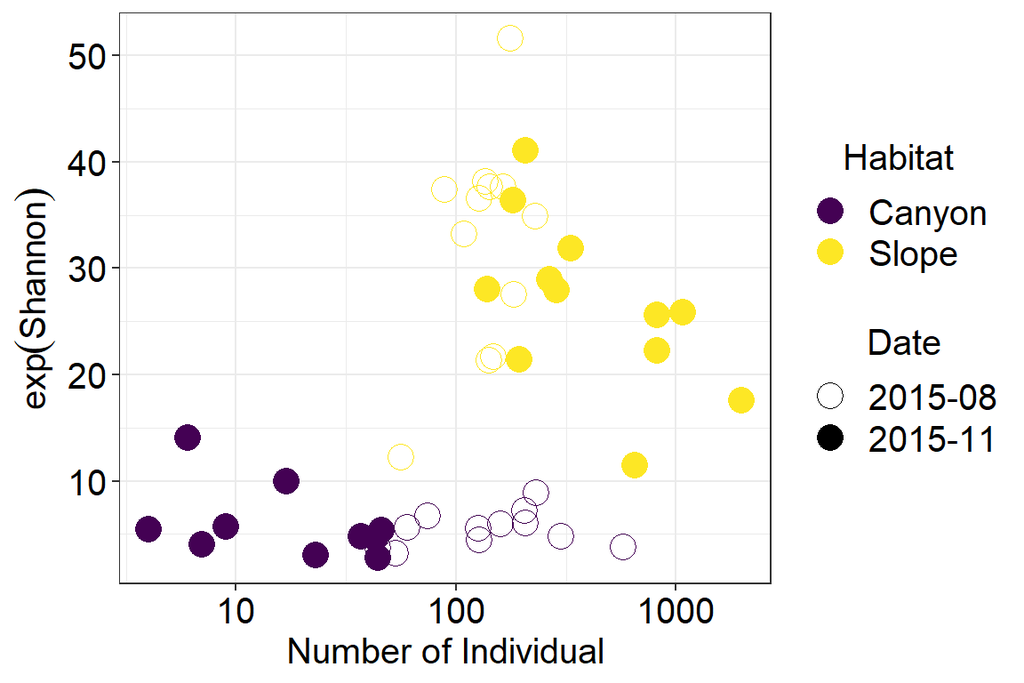

```r
out <- cbind(h1, Abund=nema_total$Abundance,e)
out$Date <- factor(out$Cruise, labels=c("2015-08", "2015-11"))
ggplot(data=out, aes(x=Abund, y=qD, colour=Habitat, shape=Date))+
  geom_point(size=5)+
  labs(x="Number of Individual", y=expression(exp(Shannon)))+
  scale_shape_manual(values=c(1, 19))+
  scale_x_log10()+
  scale_color_viridis(discrete = TRUE)+
  theme_bw() %+replace% large
```

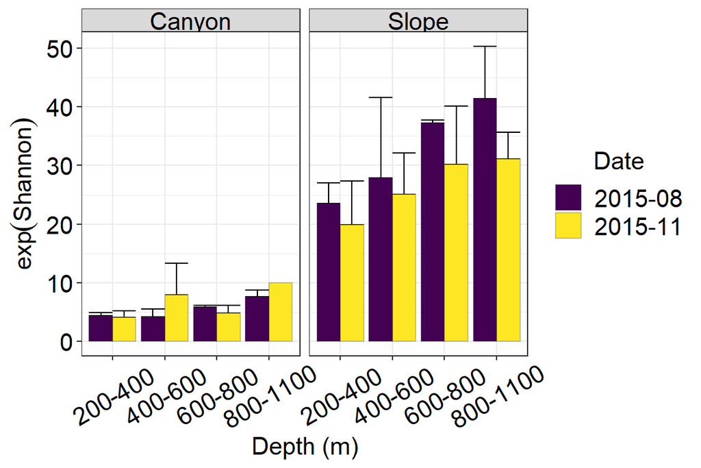

```r
out <- summaryBy(qD~Cruise+Station+Habitat+Zone, data=cbind(h1, e), FUN=c(mean, sd))
out$Date <- factor(out$Cruise, labels=c("2015-08", "2015-11"))
names(out)[5:6] <- c("qD", "sd")

ggplot(data=out, aes(x=Zone, y=qD, ymin=qD, ymax=qD+sd, fill=Date))+
  geom_errorbar(position="dodge")+
  geom_bar(stat="identity", position="dodge", colour=gray(0, 0.2))+
  facet_wrap(~Habitat)+
  labs(x="Depth (m)", y=expression(exp(Shannon)))+
  scale_fill_viridis(discrete = TRUE)+
  scale_color_viridis(discrete = TRUE)+
  theme_bw() %+replace% large %+replace% theme(axis.text.x=element_text(angle=30))
```

## q=2 or inverse Simpson diversity

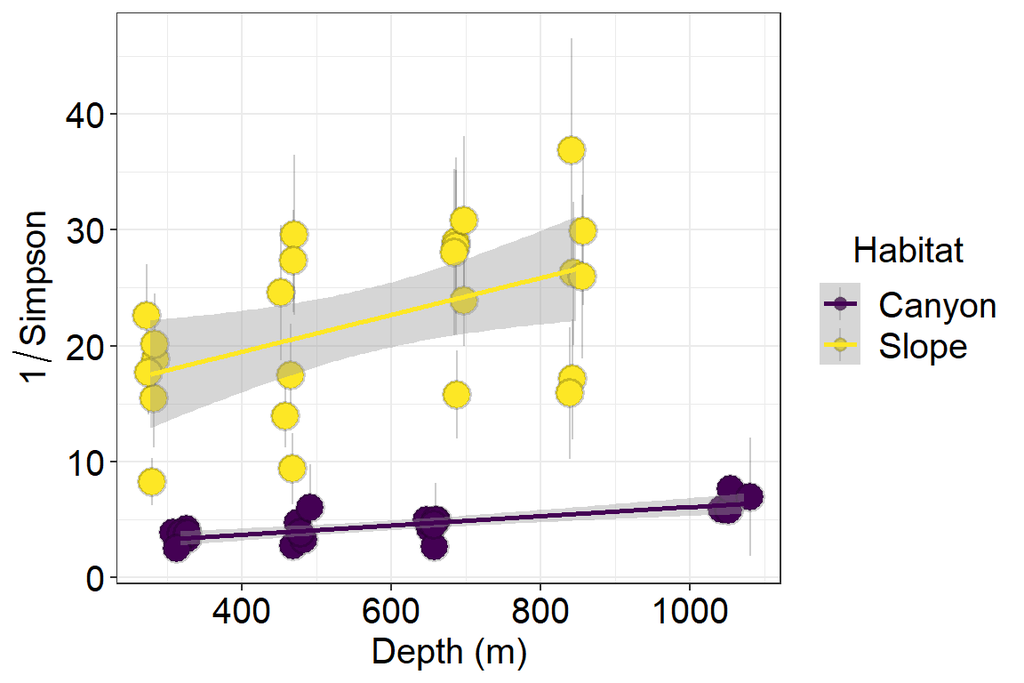

```r
ggplot(data=cbind(h2, e),
       aes(x=Depth, y=qD, ymin=qD.LCL, ymax=qD.UCL, colour=Habitat))+
  geom_pointrange(aes(fill=Habitat), pch=21, colour=gray(0, 0.2), fatten = 10,
                  position=position_jitter(width=10))+
  stat_smooth(method="lm", fill="gray60")+
  labs(x="Depth (m)", y=expression(1/Simpson))+
  scale_fill_viridis(discrete = TRUE)+
  scale_color_viridis(discrete = TRUE)+
  theme_bw() %+replace% large
```

```r
# Linear regression
hl <- splitBy(~Habitat, cbind(h2, e))
lapply(hl, FUN=function(x)summary(lm(qD~Depth, data=x)))
```

```
## $Canyon
##
## Call:
## lm(formula = qD ~ Depth, data = x)
##
## Residuals:
##     Min      1Q  Median      3Q     Max
## -2.0659 -0.5359  0.1741  0.5007  1.9394
##
## Coefficients:
##              Estimate Std. Error t value Pr(>|t|)
## (Intercept) 2.1319077  0.5023413   4.244 0.000439 ***
## Depth       0.0039603  0.0007758   5.105 6.29e-05 ***
## ---
## Signif. codes:  0 '***' 0.001 '**' 0.01 '*' 0.05 '.' 0.1 ' ' 1
##
## Residual standard error: 0.9174 on 19 degrees of freedom
##   (1 observation deleted due to missingness)
## Multiple R-squared:  0.5784, Adjusted R-squared:  0.5562
## F-statistic: 26.06 on 1 and 19 DF,  p-value: 6.29e-05
##
##
## $Slope
##
## Call:
## lm(formula = qD ~ Depth, data = x)
##
## Residuals:
##     Min      1Q  Median      3Q     Max
## -11.129  -3.950   0.686   4.551  10.231
##
## Coefficients:
##              Estimate Std. Error t value Pr(>|t|)
## (Intercept) 13.132642   3.746189   3.506   0.0020 **
## Depth        0.015922   0.006145   2.591   0.0167 *
## ---
## Signif. codes:  0 '***' 0.001 '**' 0.01 '*' 0.05 '.' 0.1 ' ' 1
##
## Residual standard error: 6.536 on 22 degrees of freedom
## Multiple R-squared:  0.2338, Adjusted R-squared:  0.199
## F-statistic: 6.713 on 1 and 22 DF,  p-value: 0.01668
```

```r
# Linear Mixed-Effects Models
f <- lme(fixed = qD ~ Habitat*Depth, random = ~1|Cruise, data=cbind(h2, e), method = "REML", weights=varIdent(form=~1|Cruise), na.action = na.omit)
summary(f)
```

```
## Linear mixed-effects model fit by REML
##  Data: cbind(h2, e)
##        AIC      BIC    logLik
##   291.2433 303.2383 -138.6216
##
## Random effects:
##  Formula: ~1 | Cruise
##         (Intercept) Residual
## StdDev:    1.834075 4.139066
##
## Variance function:
##  Structure: Different standard deviations per stratum
##  Formula: ~1 | Cruise
##  Parameter estimates:
## OR1_1114 OR1_1126
## 1.000000 1.248719
## Fixed effects: qD ~ Habitat * Depth
##                        Value Std.Error DF   t-value p-value
## (Intercept)         2.058367  2.779300 40 0.7406063  0.4633
## HabitatSlope       10.570759  3.593344 40 2.9417608  0.0054
## Depth               0.003418  0.003757 40 0.9097365  0.3684
## HabitatSlope:Depth  0.013983  0.005708 40 2.4497557  0.0188
##  Correlation:
##                    (Intr) HbttSl Depth
## HabitatSlope       -0.604
## Depth              -0.807  0.627
## HabitatSlope:Depth  0.531 -0.926 -0.658
##
## Standardized Within-Group Residuals:
##         Min          Q1         Med          Q3         Max
## -3.00705459 -0.30079294  0.04083582  0.45779928  2.01560791
##
## Number of Observations: 45
## Number of Groups: 2
```

```r
# General linear Models
dat <- cbind(h2, es) %>% subset(!is.na(qD))
f <- gls(qD ~ Speed+CN+Salinity+over20+TOC+transmissometer+Temperature, data=dat)
summary(f)
```

```
## Generalized least squares fit by REML
##   Model: qD ~ Speed + CN + Salinity + over20 + TOC + transmissometer +      Temperature
##   Data: dat
##        AIC      BIC    logLik
##   271.3595 285.8578 -126.6797
##
## Coefficients:
##                     Value Std.Error   t-value p-value
## (Intercept)     13.700668 0.7922849 17.292602  0.0000
## Speed           -3.018842 2.2176859 -1.361258  0.1817
## CN               1.805341 1.2630020  1.429405  0.1613
## Salinity        -1.138580 0.9946683 -1.144683  0.2597
## over20           3.388273 1.7696146  1.914695  0.0633
## TOC              4.173372 2.1862246  1.908940  0.0640
## transmissometer  5.382414 1.7646053  3.050209  0.0042
## Temperature      1.216219 0.9438771  1.288536  0.2056
##
##  Correlation:
##                 (Intr) Speed  CN     Salnty over20 TOC    trnsms
## Speed           -0.003
## CN               0.028 -0.372
## Salinity        -0.021 -0.449 -0.101
## over20           0.040 -0.391  0.310  0.184
## TOC             -0.047  0.513 -0.684  0.019 -0.028
## transmissometer  0.059  0.251  0.445 -0.313  0.362 -0.356
## Temperature     -0.044  0.041 -0.089 -0.189 -0.298  0.179 -0.248
##
## Standardized residuals:
##         Min          Q1         Med          Q3         Max
## -2.86350800 -0.33183225  0.05076939  0.52617489  2.26748893
##
## Residual standard error: 5.295325
## Degrees of freedom: 45 total; 37 residual
```

```r
# Model selection
ms <- dredge(f)
kable(ms[1:10,])
```

|  | (Intercept) | CN | over20 | Salinity | Speed | Temperature | TOC | transmissometer | df | logLik | AICc | delta | weight |
| --- | --- | --- | --- | --- | --- | --- | --- | --- | --- | --- | --- | --- | --- |
| 108 | 13.72392 | 1.811694 | 4.277721 | NA | -4.051094 | NA | 3.777107 | 5.352140 | 7 | -129.6861 | 276.3992 | 0.0000000 | 0.15903130 |
| 124 | 13.68162 | 1.659213 | 3.760043 | NA | -4.158614 | 1.012101 | 4.219891 | 4.749175 | 8 | -128.2479 | 276.4957 | 0.0965678 | 0.15153508 |
| 128 | 13.70067 | 1.805341 | 3.388273 | -1.1385803 | -3.018842 | 1.216219 | 4.173372 | 5.382414 | 9 | -126.6797 | 276.5024 | 0.1031997 | 0.15103343 |
| 112 | 13.74564 | 1.950957 | 4.067214 | -0.8964465 | -3.136636 | NA | 3.670172 | 5.946457 | 8 | -128.3683 | 276.7365 | 0.3373535 | 0.13434677 |
| 123 | 13.65426 | NA | 2.989212 | NA | -2.929274 | 1.148117 | 6.200182 | 3.781043 | 7 | -130.2606 | 277.5482 | 1.1490939 | 0.08952824 |
| 127 | 13.66880 | NA | 2.605047 | -0.9948736 | -1.838755 | 1.336939 | 6.311927 | 4.259855 | 8 | -128.8467 | 277.6935 | 1.2943386 | 0.08325696 |
| 107 | 13.69996 | NA | 3.502441 | NA | -2.676018 | NA | 5.900637 | 4.371405 | 6 | -131.8654 | 277.9414 | 1.5422504 | 0.07355077 |
| 111 | 13.71579 | NA | 3.287397 | -0.7137132 | -1.863810 | NA | 5.945460 | 4.784554 | 7 | -130.6958 | 278.4185 | 2.0193779 | 0.05794024 |
| 120 | 13.69750 | 1.165307 | 2.445945 | -1.7465072 | NA | 1.269183 | 5.700285 | 5.986103 | 8 | -129.3169 | 278.6339 | 2.2347371 | 0.05202542 |
| 119 | 13.67455 | NA | 2.135078 | -1.4607531 | NA | 1.344128 | 6.855497 | 4.968114 | 7 | -130.8891 | 278.8053 | 2.4061693 | 0.04775178 |

```r
# Model averaging
ma <- model.avg(ms, fit=TRUE)
kable(summary(ma)$coefmat.full)
```

|  | Estimate | Std. Error | Adjusted SE | z value | Pr(>\|z\|) |
| --- | --- | --- | --- | --- | --- |
| (Intercept) | 13.6947915 | 0.8088380 | 0.8348333 | 16.4042224 | 0.0000000 |
| CN | 1.1076949 | 1.4046547 | 1.4265784 | 0.7764697 | 0.4374717 |
| over20 | 2.9020860 | 2.0654856 | 2.1042532 | 1.3791525 | 0.1678478 |
| Speed | -2.5544751 | 2.4707542 | 2.5130907 | 1.0164675 | 0.3094068 |
| TOC | 4.6975853 | 2.5336827 | 2.5780892 | 1.8221190 | 0.0684369 |
| transmissometer | 4.9329451 | 1.9524130 | 1.9945957 | 2.4731554 | 0.0133926 |
| Temperature | 0.7063012 | 0.9644070 | 0.9813336 | 0.7197361 | 0.4716875 |
| Salinity | -0.6242724 | 0.9451822 | 0.9625274 | 0.6485762 | 0.5166123 |

```r
# Best model
b <- get.models(ms, subset=1)[[1]]
kable(summary(b)$tTable)
```

|  | Value | Std.Error | t-value | p-value |
| --- | --- | --- | --- | --- |
| (Intercept) | 13.723923 | 0.7962442 | 17.235823 | 0.0000000 |
| CN | 1.811694 | 1.2567719 | 1.441545 | 0.1574128 |
| over20 | 4.277721 | 1.6844578 | 2.539524 | 0.0151990 |
| Speed | -4.051094 | 1.9918535 | -2.033831 | 0.0488115 |
| TOC | 3.777107 | 2.1617020 | 1.747284 | 0.0884592 |
| transmissometer | 5.352140 | 1.5922123 | 3.361449 | 0.0017460 |

```r
# Relative importance
kable(summary(ma)$sw)
```

|  | x |
| --- | --- |
| transmissometer | 0.9785497 |
| TOC | 0.9261676 |
| over20 | 0.8552202 |
| Speed | 0.7829823 |
| CN | 0.6342833 |
| Temperature | 0.5610832 |
| Salinity | 0.5350290 |

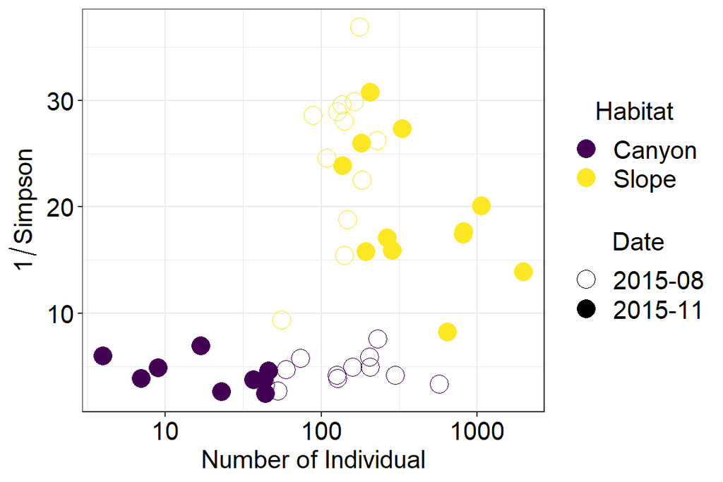

```r
out <- cbind(h2, Abund=nema_total$Abundance,e)
out$Date <- factor(out$Cruise, labels=c("2015-08", "2015-11"))
ggplot(data=out, aes(x=Abund, y=qD, colour=Habitat, shape=Date))+
  geom_point(size=5)+
  labs(x="Number of Individual", y=expression(1/Simpson))+
  scale_shape_manual(values=c(1, 19))+
  scale_x_log10()+
  scale_color_viridis(discrete = TRUE)+
  theme_bw() %+replace% large
```

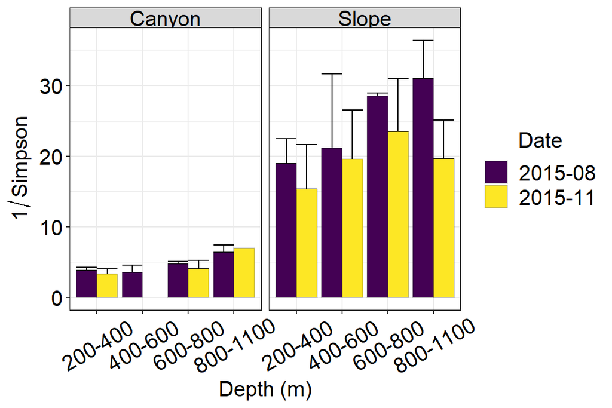

```r
out <- summaryBy(qD~Cruise+Station+Habitat+Zone, data=cbind(h2, e), FUN=c(mean, sd))
out$Date <- factor(out$Cruise, labels=c("2015-08", "2015-11"))
names(out)[5:6] <- c("qD", "sd")

ggplot(data=out, aes(x=Zone, y=qD, ymin=qD, ymax=qD+sd, fill=Date))+
  geom_errorbar(position="dodge")+
  geom_bar(stat="identity", position="dodge", colour=gray(0, 0.2))+
  facet_wrap(~Habitat)+
  labs(x="Depth (m)", y=expression(1/Simpson))+
  scale_fill_viridis(discrete = TRUE)+
  scale_color_viridis(discrete = TRUE)+
  theme_bw() %+replace% large %+replace% theme(axis.text.x=element_text(angle=30))
```

# Correlation bettwen exponential Shannon (q=1) and environmental factor

```r
p1 <- ggplot(data=cbind(h1, e),
       aes(x=Speed, y=qD, ymin=qD.LCL, ymax=qD.UCL))+
  geom_pointrange(aes(fill=Habitat), pch=21, colour=gray(0, 0.2), fatten=10)+
  stat_smooth(method="lm", fill="gray60", colour="gray50")+
  labs(x="Modeled Current Velocity (m/s)", y="Shannon Diversity")+
  scale_fill_viridis(discrete = TRUE)+
  scale_color_viridis(discrete = TRUE)+
  theme_bw() %+replace% large %+replace% theme(legend.position="none")

cor.test(formula=~qD+Speed, data=cbind(h1, e))
```

```
##
##  Pearson's product-moment correlation
##
## data:  qD and Speed
## t = -8.2344, df = 44, p-value = 1.863e-10
## alternative hypothesis: true correlation is not equal to 0
## 95 percent confidence interval:
##  -0.8719339 -0.6311391
## sample estimates:
##        cor
## -0.7787549
```

```r
p2 <- ggplot(data=cbind(h1, e),
       aes(x=over20, y=qD, ymin=qD.LCL, ymax=qD.UCL))+
  geom_pointrange(aes(fill=Habitat), pch=21, colour=gray(0, 0.2), fatten=10)+
  stat_smooth(method="lm", fill="gray60", colour="gray50")+
  labs(x="Modeled Duration of Erosion (hr)", y="Shannon Diversity")+
  scale_fill_viridis(discrete = TRUE)+
  scale_color_viridis(discrete = TRUE)+
  theme_bw() %+replace% large %+replace% theme(legend.position="none")

cor.test(formula=~qD+over20, data=cbind(h1, e))
```

```
##
##  Pearson's product-moment correlation
##
## data:  qD and over20
## t = -5.6372, df = 44, p-value = 1.149e-06
## alternative hypothesis: true correlation is not equal to 0
## 95 percent confidence interval:
##  -0.7894639 -0.4399942
## sample estimates:
##        cor
## -0.6475775
```

```r
p3 <- ggplot(data=cbind(h1, e),
       aes(x=transmissometer, y=qD, ymin=qD.LCL, ymax=qD.UCL))+
  geom_pointrange(aes(fill=Habitat), pch=21, colour=gray(0, 0.2), fatten=10)+
  stat_smooth(method="lm", fill="gray60", colour="gray50")+
  labs(x="Light Transmission (%)", y="")+
  scale_fill_viridis(discrete = TRUE)+
  scale_color_viridis(discrete = TRUE)+
  theme_bw() %+replace% large %+replace% theme(legend.position="none")

cor.test(formula=~qD+transmissometer, data=cbind(h1, e))
```

```
##
##  Pearson's product-moment correlation
##
## data:  qD and transmissometer
## t = 8.3055, df = 44, p-value = 1.475e-10
## alternative hypothesis: true correlation is not equal to 0
## 95 percent confidence interval:
##  0.6351574 0.8735324
## sample estimates:
##       cor
## 0.7813806
```

```r
p4 <- ggplot(data=cbind(h1, e),
       aes(x=TOC, y=qD, ymin=qD.LCL, ymax=qD.UCL))+
  geom_pointrange(aes(fill=Habitat), pch=21, colour=gray(0, 0.2), fatten=10)+
  stat_smooth(method="lm", fill="gray60", colour="gray50")+
  labs(x="Total Organic Carbon (%)", y="")+
  scale_fill_viridis(discrete = TRUE)+
  scale_color_viridis(discrete = TRUE)+
  theme_bw() %+replace% large %+replace% theme(legend.position="none")

cor.test(formula=~qD+TOC, data=cbind(h1, e))
```

```
##
##  Pearson's product-moment correlation
##
## data:  qD and TOC
## t = 9.4526, df = 44, p-value = 3.682e-12
## alternative hypothesis: true correlation is not equal to 0
## 95 percent confidence interval:
##  0.6929232 0.8959576
## sample estimates:
##       cor
## 0.8185637
```

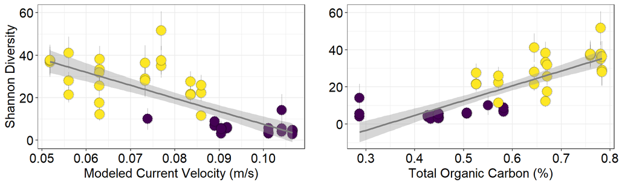

```r
plot_grid(p1, p4, ncol=2, align = "h", axis="b")
```

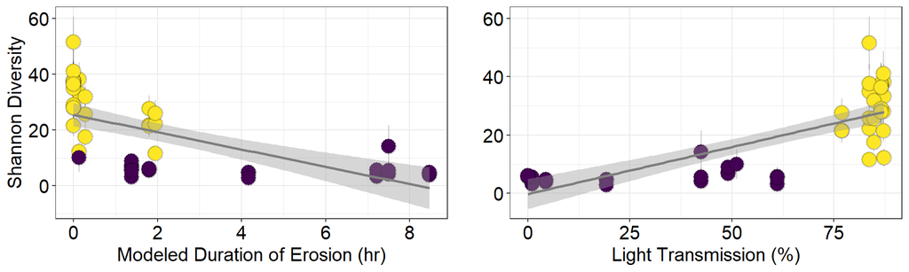

```r
plot_grid(p2, p3, ncol=2, align = "h", axis="b")
```

```r
out <- cbind(e[, 1:5], q0$DataInfo[,2:4], "0D"=h0$qD, "1D" = h1$qD, "2D"=h2$qD)
row.names(out) <- NULL
# Outliers, the confidence interval too large
out[out$Cruise=="OR1_1126" & out$Station=="GC2" & out$Subcore == 2, c("2D")] <- NA
out[out$Cruise=="OR1_1126" & out$Station=="GC2" & out$Subcore == 3, c("1D", "2D")] <- NA
kable(out)
```

| Cruise | Station | Deployment | Tube | Subcore | n | S.obs | SC | 0D | 1D | 2D |
| --- | --- | --- | --- | --- | --- | --- | --- | --- | --- | --- |
| OR1_1114 | GC1 | 2 | 11 | 1 | 100 | 11 | 0.9602 | 5.249 | 4.477 | 3.892 |
| OR1_1114 | GC1 | 2 | 11 | 2 | 100 | 9 | 0.9802 | 4.404 | 3.796 | 3.327 |
| OR1_1114 | GC1 | 2 | 11 | 3 | 100 | 11 | 0.9602 | 5.480 | 4.747 | 4.179 |
| OR1_1114 | GC2 | 1 | 1 | 1 | 53 | 7 | 0.9637 | 3.807 | 3.156 | 2.674 |
| OR1_1114 | GC2 | 1 | 1 | 2 | 43 | 7 | 0.9778 | 4.393 | 3.723 | 3.216 |
| OR1_1114 | GC2 | 1 | 1 | 3 | 55 | 12 | 0.9104 | 6.955 | 5.607 | 4.700 |
| OR1_1114 | GC3 | 1 | 3 | 1 | 100 | 14 | 0.9708 | 7.449 | 5.968 | 4.932 |
| OR1_1114 | GC3 | 1 | 3 | 2 | 100 | 15 | 0.9506 | 7.560 | 5.503 | 4.190 |
| OR1_1114 | GC3 | 1 | 3 | 3 | 100 | 17 | 0.9204 | 7.820 | 6.062 | 4.939 |
| OR1_1114 | GC4 | 1 | 6 | 1 | 100 | 14 | 0.9904 | 9.130 | 7.236 | 5.856 |
| OR1_1114 | GC4 | 1 | 6 | 2 | 74 | 14 | 0.9193 | 7.932 | 6.680 | 5.742 |
| OR1_1114 | GC4 | 1 | 6 | 3 | 100 | 17 | 0.9502 | 10.610 | 8.890 | 7.610 |
| OR1_1114 | GS1 | 1 | 2 | 1 | 100 | 31 | 0.9316 | 25.471 | 21.671 | 18.791 |
| OR1_1114 | GS1 | 1 | 2 | 2 | 100 | 38 | 0.8310 | 34.938 | 27.545 | 22.532 |
| OR1_1114 | GS1 | 1 | 2 | 3 | 100 | 34 | 0.8510 | 29.289 | 21.376 | 15.411 |
| OR1_1114 | GS2 | 1 | 2 | 1 | 100 | 46 | 0.7820 | 48.878 | 38.157 | 29.583 |
| OR1_1114 | GS2 | 1 | 2 | 2 | 49 | 18 | 0.8392 | 16.232 | 12.230 | 9.360 |
| OR1_1114 | GS2 | 1 | 2 | 3 | 100 | 43 | 0.7818 | 46.092 | 33.248 | 24.547 |
| OR1_1114 | GS3 | 1 | 6 | 1 | 100 | 45 | 0.7822 | 47.475 | 36.600 | 28.938 |
| OR1_1114 | GS3 | 1 | 6 | 2 | 83 | 41 | 0.7373 | 48.945 | 37.370 | 28.580 |
| OR1_1114 | GS3 | 1 | 6 | 3 | 100 | 46 | 0.7720 | 50.009 | 37.673 | 28.053 |
| OR1_1114 | GS4 | 1 | 4 | 1 | 100 | 45 | 0.7928 | 46.009 | 34.918 | 26.221 |
| OR1_1114 | GS4 | 1 | 4 | 2 | 100 | 54 | 0.6926 | 67.584 | 51.585 | 36.866 |
| OR1_1114 | GS4 | 1 | 4 | 3 | 100 | 45 | 0.7718 | 49.434 | 37.606 | 29.843 |
| OR1_1126 | GC1 | 1 | 11 | 1 | 43 | 9 | 0.9566 | 6.009 | 4.596 | 3.743 |
| OR1_1126 | GC1 | 1 | 11 | 2 | 37 | 10 | 0.8393 | 6.649 | 4.781 | 3.747 |
| OR1_1126 | GC1 | 1 | 11 | 3 | 44 | 6 | 0.9566 | 3.149 | 2.758 | 2.451 |
| OR1_1126 | GC2 | 1 | 9 | 1 | 6 | 4 | 0.7619 | 4.238 | 4.029 | 3.889 |
| OR1_1126 | GC2 | 1 | 9 | 2 | 3 | 3 | 0.3333 | 4.407 | 5.481 | NA |
| OR1_1126 | GC2 | 1 | 9 | 3 | 5 | 5 | 0.1111 | 11.270 | NA | NA |
| OR1_1126 | GC3 | 1 | 12 | 1 | 8 | 5 | 0.6576 | 6.656 | 5.682 | 4.900 |
| OR1_1126 | GC3 | 1 | 12 | 2 | 17 | 5 | 0.8893 | 3.656 | 3.067 | 2.660 |
| OR1_1126 | GC3 | 1 | 12 | 3 | 42 | 9 | 0.9535 | 6.477 | 5.386 | 4.562 |
| OR1_1126 | GC4 | 3 | 2 | 1 | 15 | 9 | 0.6182 | 13.219 | 9.976 | 6.954 |
| OR1_1126 | GS1 | 1 | 5 | 1 | 100 | 25 | 0.8806 | 16.735 | 11.492 | 8.248 |
| OR1_1126 | GS1 | 1 | 5 | 2 | 100 | 34 | 0.8510 | 28.759 | 22.248 | 17.699 |
| OR1_1126 | GS1 | 1 | 5 | 3 | 100 | 37 | 0.8210 | 34.767 | 25.864 | 20.116 |
| OR1_1126 | GS2 | 1 | 6 | 1 | 100 | 30 | 0.8606 | 23.096 | 17.538 | 13.903 |
| OR1_1126 | GS2 | 1 | 6 | 2 | 100 | 41 | 0.8622 | 37.527 | 31.850 | 27.327 |
| OR1_1126 | GS2 | 1 | 6 | 3 | 100 | 39 | 0.8326 | 37.373 | 25.618 | 17.439 |
| OR1_1126 | GS3 | 2 | 1 | 1 | 100 | 38 | 0.8514 | 33.925 | 28.031 | 23.886 |
| OR1_1126 | GS3 | 2 | 1 | 2 | 100 | 34 | 0.8620 | 29.870 | 21.451 | 15.782 |
| OR1_1126 | GS3 | 2 | 1 | 3 | 100 | 47 | 0.7418 | 56.434 | 41.073 | 30.752 |
| OR1_1126 | GS4 | 1 | 8 | 1 | 100 | 37 | 0.7704 | 58.076 | 28.987 | 17.103 |
| OR1_1126 | GS4 | 1 | 8 | 2 | 100 | 40 | 0.7612 | 49.062 | 27.959 | 15.921 |
| OR1_1126 | GS4 | 1 | 8 | 3 | 100 | 43 | 0.7610 | 53.995 | 36.363 | 25.953 |